# Resampling: Test de permutación, Simulación de Monte Carlo y Bootstrapping

Joaquín Amat Rodrigo j.amatrodrigo@gmail.com

Mayo, 2016

Formato PDF: [Github](https://github.com/JoaquinAmatRodrigo/Estadistica-con-R)

# Introducción

Los métodos basados en remuestreo (*resampling*) se engloban dentro de los test no paramétricos ya que no requieren de ninguna asunción sobre la distribución de la o las poblaciones estudiadas. Son por lo tanto, una alternativa a los test paramétricos (*t-test*, *anova…*) cuando no se satisfacen las condiciones del Teorema del Límite Central o cuando se quiere hacer inferencia sobre un parámetro distinto a la media. A lo largo de este documento se describe la idea general de los métodos de *resampling* más utilizados.

# Test de permutaciones

El test de permutaciones es un test de significancia estadística para el estudio de diferencias entre grupos. Fue desarrollado por Ronald Fisher y E.J.G. Pitman en 1930. La distribución del estadístico estudiado (media, mediana…) se obtiene calculando el valor de dicho estadístico para todas las posibles reorganizaciones de las observaciones en los distintos grupos. Dado que implica calcular todas las posibles situaciones, se trata de un test exacto.

Para ilustrar la idea de los test de permutación se plantea un experimento simple. Supóngase un conjunto de sujetos que se distribuye en dos grupos, *A* y *B*, de tamaños $n_{A}$ y $n_{B}$, cuyas medias muestrales tras realizar el experimento resultan ser $\bar{x}_{A}$ y $\bar{x}_{B}$. Se desea determinar si existe una diferencia significativa entre la media de los dos grupos, o lo que es lo mismo, comprobar si hay evidencias en contra de la hipótesis nula de que la diferencia observada es debida, únicamente, a la asignación aleatoria de los sujetos a los dos grupos y que ambas muestras proceden realmente de la misma población. Para solucionarlo se aplica un test de permutación:

- En primer lugar, se calcula la diferencia entre las medias de los dos grupos, lo que se conoce como diferencia observada $(Dif_{observada})$.
- Todas las observaciones se combinan juntas sin tener en cuenta el grupo al que pertenecían.
- Se calculan todas las posibles permutaciones en las que las observaciones pueden ser distribuidas en dos grupos de tamaño $n_{A}$ y $n_{B}$.
- Para cada permutación, se calcula la diferencia entre medias $(Dif_{calculada})$. El conjunto de valores calculados forman la distribución exacta de las posibles diferencias siendo cierta la hipótesis nula. A esta distribución se le conoce como *permutation distribution of the mean difference*.
- El *p-value* de dos colas se calcula como la proporción de permutaciones en las que, el valor absoluto de la diferencia calculada, es mayor o igual al valor absoluto de la diferencia observada.

En este ejemplo se emplea como estadístico la media pero podría ser cualquier otro (mediana, varianza…)

La condición necesaria para un test de permutaciones se conoce como *exchangeability*, según la cual, todas las posibles permutaciones tienen la misma probabilidad de ocurrir siendo cierta la hipótesis nula. Las conclusiones de un test de permutación solo son aplicables a diseños de tipo experimental, en los que, tras haber elegido los sujetos del estudio, se realiza una asignación aleatoria a los diferentes grupos.

Los test de permutación son test de significancia y por lo tanto se emplean para calcular *p-values*, no para intervalos de confianza.

# Simulación de Monte Carlo o randomization test

En los test de permutación, el *p-value* obtenido es exacto ya que se calculan todas las posibles permutaciones de las observaciones. Esto resulta complicado o imposible cuando el tamaño muestral es mediano o grande. La simulación de Monte Carlo consiste en realizar el test empleando únicamente una muestra aleatoria de todas las posibles permutaciones, evitando así tener que calcularlas todas. Al no calcularse todas las posibles permutaciones, no es un test exacto sino aproximado.

El método de Monte Carlo no es insesgado, lo que hace necesaria una corrección (Davison and Hinkley) tal que:
$$p_{value}=\frac{r+1}{k+1}$$
siendo *r* el número de permutaciones igual o más extremas que el estadístico observado y *k* el número de permutaciones empleadas en la simulación.

A pesar de que la corrección es mínima cuando el número de simulaciones es alto, presenta la ventaja de que, si el valor observado es mayor que cualquiera de los calculados, el *p-value* es muy bajo pero no cero. Por facilidades de cálculo se suele emplear un número de permutaciones terminado en 9 (4999, 9999).

# Bootstrapping

El escenario ideal para realizar inferencia estadística sobre una población es disponer de infinitas (o una gran cantidad) de muestras de dicha población, sin embargo, en la práctica, raramente es posible. Si solo se dispone de una muestra, y esta es representativa de la población, los valores de la variable aleatoria en la muestra aparecen aproximadamente con la misma proporción que en la población. El método de *Bootstrapping* se basa en generar nuevas pseudomuestras del mismo tamaño que la muestra real mediante muestreo con reemplazo (*sampling with replacement*) de las observaciones. Si la muestra original es representativa de la población, la distribución del estadístico calculada a partir de las pseudomuestras (*bootstraping distribution*) se asemejará a la distribución muestral que se obtendría si se pudiera acceder a la población para generar nuevas muestras. Esta idea fue desarrollado por Bradley Efron en 1979.

Dado que se podrían generar infinitas nuevas muestras mediante el *sampling with replacement*, el método de *bootstrapping* emplea únicamente una cantidad determinada por el usuario. Hace uso, por lo tanto, de la simulación de Monte Carlo.

El *bootstrapping* no asume una asignación aleatoria de los grupos, sino que las muestras han sido obtenidas aleatoriamente de la o las poblaciones. Se aplica por lo tanto en diseños muestrales, no experimentales. Esta es la diferencia clave respecto a los test de permutación.

El método *bootstrapping* se puede emplear para:

- **Calcular intervalos de confianza de un parámetro poblacional**: se emplea el *sampling with replacement* a partir de la muestra original.
- **Calcular significancia estadística (*p-value*) para la diferencia entre dos poblaciones**: Si bien este uso se asemeja al de los test de permutación, no es igual. Los test de permutación contrastan la hipótesis nula de que las muestras pertenecen a una misma población (distribución) mediante el estudio de las diferencias debidas a la asignación aleatoria de los grupos. El método de *bootstrapping* también contrasta la hipótesis de que ambas muestras proceden de la misma población (distribución), pero lo hace mediante el estudio de las diferencias debidas al muestreo aleatorio. Se aplica por lo tanto a estudios en los que no ha habido una asignación aleatoria a los grupos previa realización de los experimentos. Los pasos a seguir son: se mezclan las observaciones de ambas muestras (*pool*), se emplea el *sampling with replacement* sobre este *pool* para generar una nueva pseudomuestra del mismo tamaño, se separan las observaciones de la pseudomuestra en dos grupos de igual tamaño a los originales y se calcula la diferencia del estadístico entre ambas. El proceso se repite múltiples veces generando así la distribución de las diferencias esperadas debido al muestreo aleatorio. El *p-value* de dos colas se calcula como la proporción de pseudomuestras en las que el valor absoluto de la diferencia calculada es mayor o igual al valor absoluto de la diferencia observada.
- **Calcular intervalos de confianza para la diferencia entre dos poblaciones**: para esta finalidad, se considera como hipótesis nula que las observaciones proceden de dos poblaciones distintas. Se emplea el *sampling with replacement* con la observaciones de cada muestra (sin mezclarlas) para generar dos nuevas pseudomuestras independientes y se calcula la diferencia del estadístico. Este proceso se repite múltiples veces, generando así la distribución que se obtendría si se obtuviesen cada vez dos muestras, cada una de su respectiva población, y se calculara la diferencia. La distribución resultante está centrada en la verdadera diferencia entre las poblaciones.

El método de *bootstrapping* se subdivide en paramétrico o no paramétrico dependiendo si se considera que la distribución generada sigue un determinado modelo teórico.

# Comparación de los test de permutación y métodos bootstrapping

Tanto los test de permutación como los test de *bootstrap* se pueden emplear para estudiar diferencias entre grupos. Existe una lista muy extensa de referencias en las que se debate cuál de los dos métodos es el más adecuado. En general, todas ellas concluyen en que el método más adecuado depende del objetivo de la inferencia, y a su vez, el objetivo de la inferencia determina que diseño de estudio a seguir. La siguiente tabla contiene los diferentes tipos de diseños que se pueden emplear para comparar dos grupos y el tipo de inferencia (conclusiones) que se puede realizar en cada uno:

| Muestreo aleatorio | Asignación de grupos aleatoria | Objetivo de la inferencia | Permite determinar causalidad |
| --- | --- | --- | --- |
| Sí | No | Población | No |
| No | Sí | Muestra | Sí |
| Sí | Sí | Población y Muestra | Sí |

La principal diferencia entre ambos métodos aparece cuando se emplean para calcular *p-values*. Los test de significancia (cálculo de *p-value*) se basan en la hipótesis nula de que todas las observaciones proceden de la misma población. El objetivo del test es determinar si la diferencia observada entre los grupos se debe a un determinado factor (tratamiento) o solo a la variabilidad esperada por la naturaleza de un proceso aleatorio. Cuando la aleatoriedad se debe a la asignación de los sujetos (supuestamente iguales) a los distintos grupos, se emplean los test de permutación. La estructura de un experimento que puede analizarse mediante test de permutación es: selección de sujetos del estudio, asignación aleatoria a diferentes grupos, aplicación de o los “tratamientos” y comparación de resultados. Los test de permutación responden a la pregunta ¿Cuánta variabilidad se espera en un determinado test estadístico debido únicamente a la aleatoriedad de las asignaciones, si todos los sujetos proceden realmente de una misma población? Cuando se compara la media entre dos grupos, la pregunta anterior equivale a ¿Qué diferencia entre medias cabe esperar dependiendo de cómo se distribuyan los sujetos en los dos grupos, si todos proceden de una misma población? (Aun siendo todos de una misma población, dado que no serán exactamente idénticos, habrá pequeñas diferencias dependiendo de cómo se agrupen).

El *bootstraping* como test de significancia se emplea cuando la aleatoriedad es debida al proceso de obtención de las muestras y no a la asignación en grupos. Responden a la pregunta ¿Cuánta variabilidad se espera en un determinado estadístico debido únicamente al muestreo aleatorio, si todos los sujetos proceden realmente de una misma población? Debido a las pequeñas diferencias entre los individuos de una población, si se extraen dos muestras aleatorias de ella y se comparan, no van a ser exactamente iguales, además, esta diferencia será distinta para cada par de muestras aleatorias extraídas. La estructura de un experimento que puede analizarse mediante *bootstrapping* es: Se obtienen dos muestras aleatorias de dos poblaciones y se comparan.

En conclusión, aunque ambos test pueden emplearse para calcular *p-values*, sus aplicaciones no se solapan. Los test de permutación y *randomization* se emplean para diseños experimentales, mientras que el *bootstraping* se emplea para diseños muestrales.

El método de *bootstrapping* puede emplearse, además, para generar intervalos de confianza de la verdadera diferencia de un parámetro entre dos poblaciones, mientras que los test de permutación no. El porqué reside en que la simulación que se realiza en el *bootstrapping*. Cuando se emplea por separado para cada muestra, se genera una aproximación de la verdadera distribución del estadístico que se está estudiando, lo que permite generar intervalos de confianza que acoten su valor con una determinada seguridad. Cuando se quiere calcular un *p-value*, se tiene que comparar el valor observado del estadístico con la distribución que cabría esperar de él bajo la hipótesis nula, no respecto a su verdadera distribución. Los test de permutación y los test de *bootstrapping* (aplicado al conjunto de observaciones mezcladas), generan la distribución esperada si se cumple la $H_0$.

Es importante tener en cuenta que ninguno de estos métodos está al margen de los problemas que implica tener muestras pequeñas.

# Test de permutación exacto

Este tipo de test solo es posible aplicarlo cuando el tamaño de las muestras es limitado, ya que implica generar todas las posibles permutaciones de los datos y calcular para cada una de ellas el estadístico de interés. *No he encontrado en R ningún paquete que lo realice*

# Test de permutación con simulación de Monte Carlo

## Ejemplo1

*Supóngase un estudio que pretende determinar si la participación en actividades extraescolares aumenta la capacidad empática de los estudiantes. Para ello, el colegio ofrece un programa voluntario en el que cada participante se designa de forma aleatoria a un grupo “control” que no recibe clases extraescolares o a un grupo “tratamiento” que sí las recibe. A final del año, todos los sujetos del estudio realizan un examen que determina su capacidad empática. En vista de los resultados ¿Se puede considerar que las clases extraescolares tienen un impacto en cómo se relacionan socialmente (en promedio) los estudiantes?*

Ejemplo obtenido del libro *Comparing Groups Randomization and Bootstrap Methods Using R*. Los datos ya no están disponibles en la página web del libro, pero puede encontrarse en [Github](https://github.com/JoaquinAmatRodrigo/Estadistica-con-R/tree/master/datos).

```r
library(tidyverse)
datos <- read_csv("./datos/AfterSchool.csv")
datos <- datos %>% select(Treatment, Delinq)
datos <- datos %>% rename(grupo = Treatment, puntuacion = Delinq)
datos <- datos %>% mutate(grupo =  recode(grupo, `0` = "control",
                                                 `1` = "tratamiento"))
head(datos)
```

```
## # A tibble: 6 x 2
##   grupo   puntuacion
##   <chr>        <dbl>
## 1 control       44.5
## 2 control       76.8
## 3 control       50.9
## 4 control       44.5
## 5 control       44.5
## 6 control       50.9
```

El diseño experimental del estudio emplea una asignación aleatoria de los sujetos a dos grupos (*tratamiento* y *control*) para llevar a cabo el experimento. Esta aleatorización en la asignación implica que, en promedio, los dos grupos son iguales para todas las características, por lo que la única diferencia entre ellos es si reciben o no el tratamiento. Determinar si la diferencia observada es significativa, equivale a preguntarse cómo de probable es obtener esta misma diferencia si el tratamiento no tiene efecto, o lo que es lo mismo, determinar si la diferencia observada es mayor de lo que cabría esperar debido únicamente a la variabilidad producida por la formación aleatoria de los grupos.

El diseño experimental de asignación aleatoria a grupos permite obtener conclusiones de tipo causa efecto. Sin embargo, dado que la selección de los sujetos no ha sido aleatoria, sino por voluntarios, no son extrapolables a toda la población.

**Analisis exploratorio de los datos**

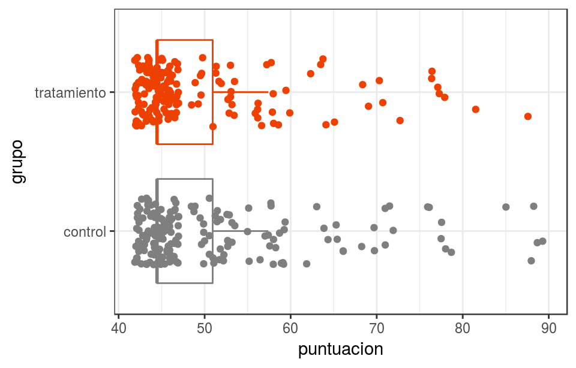

```r
ggplot(data = datos, aes(x = grupo, y = puntuacion, colour = grupo)) +
    geom_boxplot(outlier.shape = NA) +
    geom_jitter(width = 0.25) +
    scale_color_manual(values = c("gray50", "orangered2")) +
    coord_flip() +
    theme_bw() +
    theme(legend.position = "none")
```

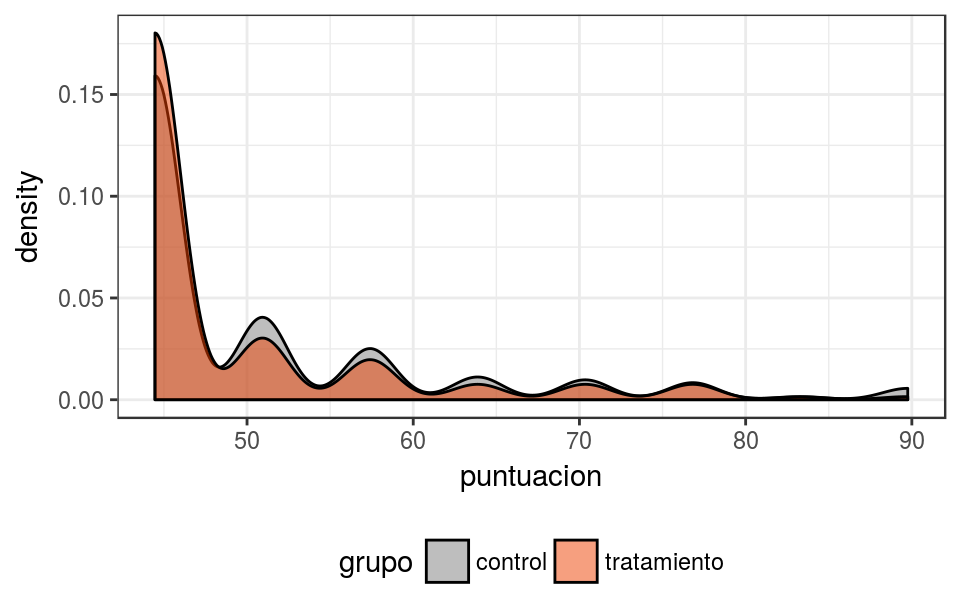

```r
ggplot(data = datos, aes(x = puntuacion, fill = grupo)) +
    geom_density(alpha = 0.5) +
    scale_fill_manual(values = c("gray50", "orangered2")) +
    theme_bw() +
    theme(legend.position = "bottom")
```

La representación gráfica muestra una clara distribución asimétrica de los valores, con una cola pronunciada hacia la derecha en ambos grupos. No se observa una diferencia evidente entre grupos.

```r
datos %>% group_by(grupo) %>% summarise(media = mean(puntuacion),
                                        sd = sd(puntuacion),
                                        mediana = median(puntuacion))
```

```
## # A tibble: 2 x 4
##   grupo       media    sd mediana
##   <chr>       <dbl> <dbl>   <dbl>
## 1 control      50.7 10.5     44.5
## 2 tratamiento  49.0  8.97    44.5
```

Las medias de localización (media y mediana) de ambos grupos son similares. Lo mismo ocurre con su dispersión.

**Test de permutaciones**

Dado que las observaciones no se distribuyen de forma normal, los test de hipótesis paramétricos no son adecuados. Como alternativa, se recurre a un test no paramétrico basado en *resampling*. Al tratarse de un diseño experimental en el que se ha partiendo de un conjunto de sujetos y se han asignado aleatoriamente a cada grupo, el test adecuado es el de permutaciones.

En primer lugar se calcula la diferencia entre las medias de ambos grupos (diferencia observada).

```r
media_control <- datos %>% filter(grupo == "control") %>%
                           pull(puntuacion) %>%
                           mean()
media_tratamiento <- datos %>% filter(grupo == "tratamiento") %>%
                           pull(puntuacion) %>%
                           mean()
dif_obs <- media_control - media_tratamiento
dif_obs
```

```
## [1] 1.706636
```

Determinar si la diferencia observada es significativa equivale a preguntarse cómo de probable es obtener esta diferencia si el tratamiento no tiene efecto y los estudiantes se han asignado de forma aleatoria en cada grupo. Para poder obtener la probabilidad exacta, se necesita generar todas las posibles permutaciones en las que, 356 sujetos, pueden repartirse en dos grupos, y calcular la diferencia de medias para cada una. El número de permutaciones posibles es muy elevado, $(3.93x10^{105})$, por lo que se recurre a una simulación de Monte Carlo. El algoritmo seguido es:

1. Se reasignan aleatoriamente los sujetos a cada uno de los grupos manteniendo el tamaño original de cada uno.
2. Se calcula la diferencia de sus medias y se almacena el valor. Existen múltiples formas de realizar las permutaciones, lo importante es que mimeticen una asignación aleatoria de los grupos manteniendo el tamaño original.
3. Se repiten los pasos 1 y 2 *n* veces.
4. Se calcula el *p_value* como la proporción de permutaciones en las que, la diferencia absoluta obtenida, es igual o mayor a la observada.

```r
distribucion_permut <- rep(NA, 9999)
n_control <- datos %>% filter(grupo == "control") %>% nrow()
n_tratamiento <- datos %>% filter(grupo == "tratamiento") %>% nrow()

for (i in 1:9999) {
  # mezclado aleatorio de las observaciones
  datos_aleatorizados <- sample(datos$puntuacion)
  mean_control <- mean(datos_aleatorizados[1:n_control])
  mean_tratamiento <- mean(datos_aleatorizados[n_control + 1:n_tratamiento])
  distribucion_permut[i] <- mean_control - mean_tratamiento
}

head(distribucion_permut)
```

```
## [1] -0.3341206 -0.2612364  1.1964465 -0.3341206  0.4676050 -0.1883523
```

Los datos simulados forman lo que se conoce como *distribución de permutaciones o de Monte Carlo*, que representa la variación esperada en la diferencia de medias debido únicamente a la asignación aleatoria de grupos.

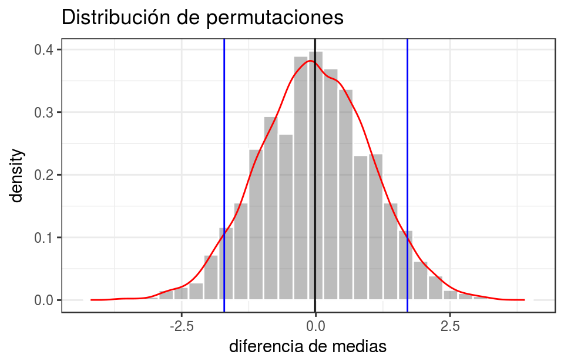

```r
ggplot(data = data.frame(permutaciones = distribucion_permut),
      aes(permutaciones)) +
  geom_histogram(aes(y = ..density..), alpha = 0.4, colour = "white") +
  geom_line(aes(y = ..density..), stat = 'density', colour = "red") +
  geom_vline(xintercept = mean(distribucion_permut)) +
  geom_vline(xintercept = dif_obs, colour = "blue") +
  geom_vline(xintercept = -dif_obs, colour = "blue") +
  labs(title = "Distribución de permutaciones", x = "diferencia de medias") +
  theme_bw()
```

```r
summary(distribucion_permut)
```

```
##     Min.  1st Qu.   Median     Mean  3rd Qu.     Max.
## -4.19698 -0.69854 -0.04258 -0.01523  0.68626  3.89316
```

```r
sd(distribucion_permut)
```

```
## [1] 1.042779
```

Como era de esperar, si el tratamiento no es efectivo, la diferencia media entre grupos es muy próxima a cero (línea vertical negra). La desviación típica (1.043) de la distribución de permutaciones indica que la variabilidad debida a la asignación aleatoria de los sujetos es muy pequeña.

Finalmente, se calcula la probabilidad (*p-value*) de obtener diferencias igual o más extremas que la observada (líneas verticales azules) con y sin corrección de continuidad.

```r
# Sin corrección
p_value = (sum(abs(distribucion_permut) > abs(dif_obs)))/9999
p_value
```

```
## [1] 0.1067107
```

```r
# Con corrección
p_value_corregido = ((sum(abs(distribucion_permut) > abs(dif_obs))) + 1)/(9999 + 1)
p_value_corregido
```

```
## [1] 0.1068
```

**Conclusión**

Los 356 sujetos del estudio fueron asignados de forma aleatoria a un grupo control (n=187) o a un grupo tratamiento (n=169) que asistió a clases extra escolares. Un test de permutación se empleó para determinar si existía una diferencia significativa en la capacidad empática promedio entre ambos grupos. El *p-value* fue calculado mediante una simulación de Monte Carlo con 9999 permutaciones usando la corrección de continuidad sugerida por Davison and Hikley(1997). El *p-value* obtenido muestra una evidencia muy débil en contra de la hipótesis nula de que el tratamiento no tiene efecto, sugiriendo que asistir a clases extra escolares no mejora la capacidad empática para los estudiantes que formaron parte del experimento. *Siendo estadísticamente estrictos, no se puede extrapolar a la población de estudiantes ya que la selección de sujetos no fue aleatoria*.

*Ha modo de comprobación, siendo los tamaños muestrales de más de 30 observaciones, el test paramétrico t-test debería dar un resultado similar*.

```r
t.test(puntuacion ~ grupo, data = datos, var.equal = TRUE)
```

```
##
##  Two Sample t-test
##
## data:  puntuacion by grupo
## t = 1.6379, df = 354, p-value = 0.1023
## alternative hypothesis: true difference in means is not equal to 0
## 95 percent confidence interval:
##  -0.3425852  3.7558562
## sample estimates:
##     mean in group control mean in group tratamiento
##                  50.72559                  49.01896
```

## Ejemplo2

*Una investigación quiere determinar si las clases de repaso tienen un efecto significativo en el resultado de los exámenes de los estudiantes. Para ello, un conjunto de estudiantes se reparte al azar en dos grupos, uno que asiste a clases de repaso y otro que no, y se evalúa su conocimiento con un examen. ¿Existe una diferencia significativa en el promedio entre ambos grupos? Solucionarlo con t-test y test de permutación si se cumplen sus respectivas condiciones. Ejemplo del libro Bootstrap Methods ans Permutation Test by Tim Hestemberg*.

```r
grupo <- c("clases repaso", "clases repaso", "clases repaso","clases repaso",
           "clases repaso", "clases repaso", "clases repaso", "clases repaso",
           "clases repaso", "clases repaso", "clases repaso", "clases repaso",
           "clases repaso", "clases repaso", "clases repaso", "clases repaso",
           "clases repaso", "clases repaso", "clases repaso", "clases repaso",
           "clases repaso", "control", "control", "control", "control", "control",
           "control", "control", "control", "control", "control", "control",
           "control", "control", "control", "control", "control", "control",
           "control", "control", "control", "control", "control", "control")
resultado <- c(24, 43, 58, 71, 43, 49, 61, 44, 67, 49,  53, 56, 59, 52, 62,  54,
               57, 33, 46, 43, 57, 26, 62, 37, 42, 43, 55, 54, 20, 85, 33, 41, 19,
               60,  53, 42, 46, 10, 17, 28, 48, 37, 42, 55)
datos <- data_frame(grupo, resultado)
head(datos)
```

```
## # A tibble: 6 x 2
##   grupo         resultado
##   <chr>             <dbl>
## 1 clases repaso        24
## 2 clases repaso        43
## 3 clases repaso        58
## 4 clases repaso        71
## 5 clases repaso        43
## 6 clases repaso        49
```

**Exploración de los datos**

El *t-test* es un test estadístico válido para comparar medias poblacionales siempre y cuando se cumpla que los datos son independientes y que las observaciones proceden de distribuciones normales (son robustos frente a cierta asimetría si el tamaño de ambas muestras es mayor de 30).

```r
datos %>% group_by(grupo) %>%
          summarise(media = mean(resultado), mediana = median(resultado),
                    sd = sd(resultado))
```

```
## # A tibble: 2 x 4
##   grupo         media mediana    sd
##   <chr>         <dbl>   <dbl> <dbl>
## 1 clases repaso  51.5      53  11.0
## 2 control        41.5      42  17.1
```

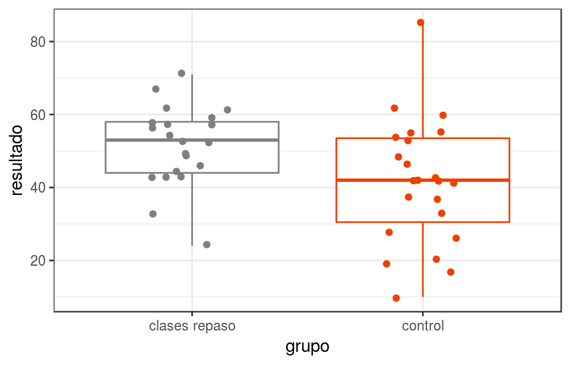

```r
ggplot(data = datos, aes(x = grupo, y = resultado, colour = grupo)) +
    geom_boxplot(outlier.shape = NA) +
    geom_jitter(width = 0.2) +
    scale_color_manual(values = c("gray50", "orangered2")) +
    theme_bw() +
    theme(legend.position = "none")
```

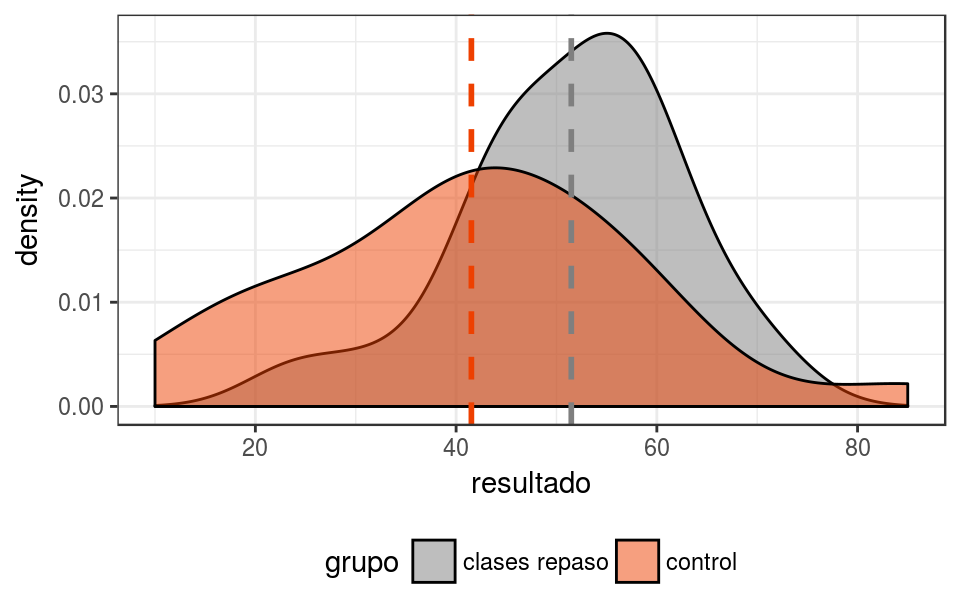

```r
ggplot(data = datos, aes(x = resultado, fill = grupo)) +
  geom_density(alpha = 0.5) +
  scale_fill_manual(values = c("gray50", "orangered2")) +
  geom_vline(xintercept = mean(datos%>%filter(grupo=="clases repaso")%>%pull(resultado)),
             color = "gray50", linetype = "dashed", size = 1) +
  geom_vline(xintercept = mean(datos%>%filter(grupo=="control")%>%pull(resultado)),
             color = "orangered2", linetype = "dashed", size = 1) +
  theme_bw() +
  theme(legend.position = "bottom")
```

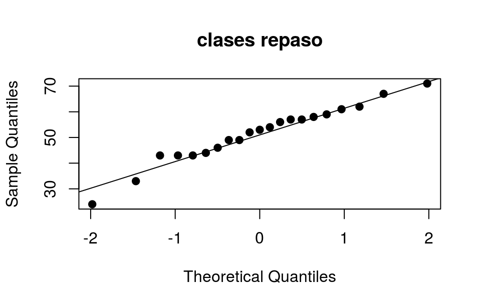

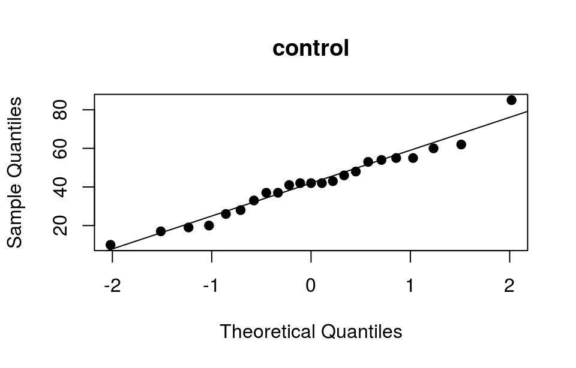

```
## # A tibble: 2 x 3
##   grupo         data              plot
##   <chr>         <list>            <chr>
## 1 clases repaso <tibble [21 × 1]> clases repaso
## 2 control       <tibble [23 × 1]> control
```

```r
cutom_qqnorm <- function(grupo, df){
  qqnorm(df$resultado, main = grupo, pch = 19)
  qqline(df$resultado)
}

datos %>% group_by(grupo) %>% nest() %>%
          mutate(plot = walk2(.x = grupo, .y = data, .f = cutom_qqnorm))
```

```r
custom_shapiro_test <- function(df){
  return(shapiro.test(df$resultado)$p.value)
}

datos %>% group_by(grupo) %>% nest() %>%
          mutate(pvalue_shapiro = map_dbl(.x = data, .f = custom_shapiro_test))
```

```
## # A tibble: 2 x 3
##   grupo         data              pvalue_shapiro
##   <chr>         <list>                     <dbl>
## 1 clases repaso <tibble [21 × 1]>          0.652
## 2 control       <tibble [23 × 1]>          0.732
```

```r
t.test(resultado ~ grupo, data = datos, altermative = "two.sided", mu = 0,
       var.equal = TRUE, paired = FALSE , conf.level = 0.95)
```

```
##
##  Two Sample t-test
##
## data:  resultado by grupo
## t = 2.2666, df = 42, p-value = 0.02863
## alternative hypothesis: true difference in means is not equal to 0
## 95 percent confidence interval:
##   1.091253 18.817650
## sample estimates:
## mean in group clases repaso       mean in group control
##                    51.47619                    41.52174
```

**Solución mediante test de permutación**

```r
distribucion_permut <- rep(NA, 9999)
n_control <- datos %>% filter(grupo == "control") %>% nrow()
n_tratamiento <- datos %>% filter(grupo == "clases repaso") %>% nrow()

for (i in 1:9999) {
  # mezclado aleatorio de las observaciones
  datos_aleatorizados <- sample(datos$resultado)
  mean_control <- mean(datos_aleatorizados[1:n_control])
  mean_tratamiento <- mean(datos_aleatorizados[n_control + 1:n_tratamiento])
  distribucion_permut[i] <- mean_control - mean_tratamiento
}

media_control <- datos %>% filter(grupo == "control") %>%
                           pull(resultado) %>%
                           mean()
media_tratamiento <- datos %>% filter(grupo == "clases repaso") %>%
                           pull(resultado) %>%
                           mean()
dif_obs <- media_control - media_tratamiento
dif_obs
```

```
## [1] -9.954451
```

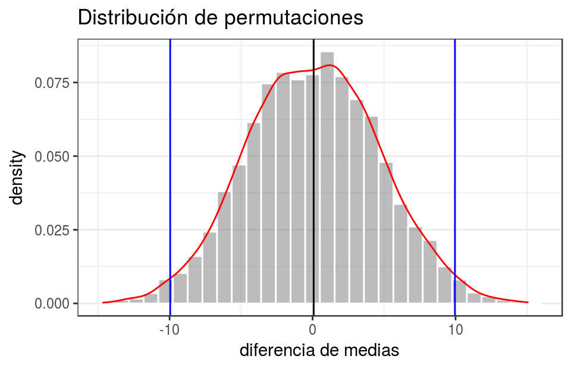

```r
ggplot(data = data.frame(permutaciones = distribucion_permut),
      aes(permutaciones)) +
  geom_histogram(aes(y = ..density..), alpha = 0.4, colour = "white") +
  geom_line(aes(y = ..density..), stat = 'density', colour = "red") +
  geom_vline(xintercept = mean(distribucion_permut)) +
  geom_vline(xintercept = dif_obs, colour = "blue") +
  geom_vline(xintercept = -dif_obs, colour = "blue") +
  labs(title = "Distribución de permutaciones", x = "diferencia de medias") +
  theme_bw()
```

```r
summary(distribucion_permut)
```

```
##      Min.   1st Qu.    Median      Mean   3rd Qu.      Max.
## -14.69151  -3.12215   0.06625   0.07648   3.25466  15.09731
```

```r
sd(distribucion_permut)
```

```
## [1] 4.598547
```

Cálculo de *p-values*

```r
# Sin corrección
p_value = (sum(abs(distribucion_permut) > abs(dif_obs)))/9999
p_value
```

```
## [1] 0.02820282
```

```r
# Con corrección
p_value_corregido = ((sum(abs(distribucion_permut) > abs(dif_obs))) + 1)/(9999 + 1)
p_value_corregido
```

```
## [1] 0.0283
```

**Conclusión**

Ambos *p-values*, el obtenido por *t-test* y por test de permutación, se asemejan mucho. Esto es debido a que, como muestra la distribución de permutaciones, la diferencia de medias se distribuye de forma normal, por lo que los *t-test* son válidos. En caso de que no fuese así, el test de permutación es una mejor opción. Existen evidencias suficientes para rechazar la hipótesis nula y concluir que sí existen evidencias significativas de que la media de los dos grupos es distinta. Las clases de repaso sí influyen en los resultados de los alumnos.

En caso de querer saber si el *t-test* es adecuado, una forma de comprobarlo es generar la *permutation distribution* y verificar si se distribuye de forma normal.

# Test de permutación para comparar varianzas

En la mayoría de casos, la comparación entre grupos se centra en estudiar diferencias en la posición de las distribuciones (media, mediana…), sin embargo, también puede ser de interés comparar si las varianzas de dos grupos son iguales. Para este tipo de estudios, se puede emplear un test de permutación en el que el estadístico empleado es la varianza.

## Ejemplo

*Supóngase el estudio de un departamento médico que quiere evaluar la si un fármaco aumenta el razonamiento matemático de los estudiantes. Se sabe que no existe diferencia en el promedio de las puntuaciones obtenidas en el examen, pero se quiere evaluar si hay diferencia en la variabilidad. Esto es interesante porque, aunque el fármaco no sea capaz de incrementar el promedio de capacidad de razonamiento, podría disminuir la diferencia entre sujetos*

La hipótesis nula considera que ambos grupos son iguales por lo que:
$$\sigma^2_{control} = \sigma^2_{tratamiento}$$
$$\sigma^2_{control} - \sigma^2_{tratamiento} = 0$$

```r
datos <- read_csv("./datos/AfterSchool.csv")
datos <- datos %>% select(Treatment, Delinq)
datos <- datos %>% rename(grupo = Treatment, puntuacion = Delinq)
datos <- datos %>% mutate(grupo =  recode(grupo, `0` = "control",
                                                 `1` = "tratamiento"))
```

La diferencia observada en las varianzas es:

```r
datos %>% group_by(grupo) %>% summarise(varianza = var(puntuacion))
```

```
## # A tibble: 2 x 2
##   grupo       varianza
##   <chr>          <dbl>
## 1 control        111.
## 2 tratamiento     80.5
```

```r
var_control <- datos %>% filter(grupo == "control") %>%
                         pull(puntuacion) %>%
                         var()
var_tratamiento <- datos %>% filter(grupo == "tratamiento") %>%
                             pull(puntuacion) %>%
                             var()
dif_obs <- var_control - var_tratamiento
dif_obs
```

```
## [1] 30.15232
```

Mediante permutaciones se obtiene la distribución de la diferencia de varianza esperada únicamente debido a la asignación aleatoria de las observaciones a cada grupo, siendo cierta la hipótesis nula.

```r
distribucion_permut <- rep(NA, 9999)
n_control <- datos %>% filter(grupo == "control") %>% nrow()
n_tratamiento <- datos %>% filter(grupo == "tratamiento") %>% nrow()

for (i in 1:9999) {
  datos_aleatorizados <- sample(datos$puntuacion)
  var_control <- var(datos_aleatorizados[1:n_control])
  var_tratamiento <- var(datos_aleatorizados[n_control + 1:n_tratamiento])
  distribucion_permut[i] <- var_control - var_tratamiento
}
```

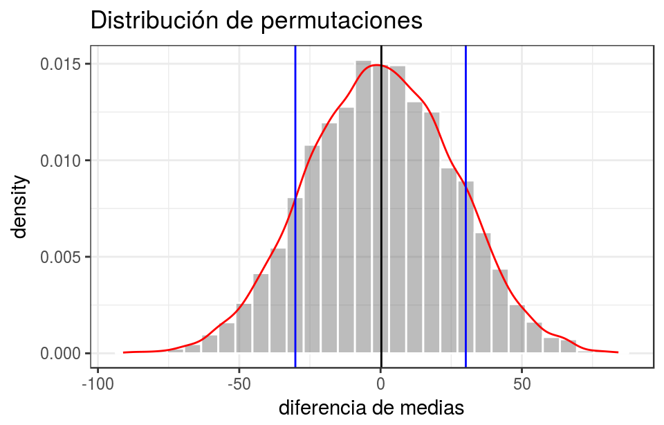

```r
ggplot(data = data.frame(permutaciones = distribucion_permut),
      aes(permutaciones)) +
  geom_histogram(aes(y = ..density..), alpha = 0.4, colour = "white") +
  geom_line(aes(y = ..density..), stat = 'density', colour = "red") +
  geom_vline(xintercept = mean(distribucion_permut)) +
  geom_vline(xintercept = dif_obs, colour = "blue") +
  geom_vline(xintercept = -dif_obs, colour = "blue") +
  labs(title = "Distribución de permutaciones", x = "diferencia de medias") +
  theme_bw()
```

```r
summary(distribucion_permut)
```

```
##     Min.  1st Qu.   Median     Mean  3rd Qu.     Max.
## -91.1112 -17.5185   0.4465   0.2847  18.1855  84.1646
```

```r
sd(distribucion_permut)
```

```
## [1] 25.68406
```

La distribución de las permutaciones muestra que la diferencia media entre varianzas, si el fármaco no tiene efecto, es muy próxima a cero (0.2847233, línea vertical negra). La desviación típica de la distribución de permutaciones indica la variabilidad de la diferencia de varianzas debida a la asignación aleatoria de los sujetos a los diferentes grupos.

Finalmente, se calcula la probabilidad (*p-value*) de obtener diferencias igual o más extremas que la observada (líneas verticales azules) con y sin corrección de continuidad:

```r
# Sin corrección
p_value = (sum(abs(distribucion_permut) > dif_obs))/9999
p_value
```

```
## [1] 0.2463246
```

```r
# Con corrección
p_value_corregido = ((sum(abs(distribucion_permut) > dif_obs)) + 1)/(9999 + 1)
p_value_corregido
```

```
## [1] 0.2464
```

**Conclusión**

Los 356 sujetos del estudio fueron asignados de forma aleatoria a un grupo control (n=187) o a un grupo tratamiento (n=169). Un test de permutación se empleó para determinar si existía una diferencia significativa en la varianza de la capacidad de razonamiento matemático entre ambos grupos. El *p-value* fue calculado mediante una simulación de Monte Carlo con 9999 permutaciones usando la corrección de continuidad sugerida por Davison and Hikley(1997). El *p-value* obtenido muestra una evidencia muy débil en contra de la hipótesis nula de que el tratamiento no tiene efecto, sugiriendo que tomar el medicamento no reduce la varianza en la capacidad de razonamiento matemático de los estudiantes que formaron parte del experimento.

# Boostraping para intervalos de confianza de una población

## Ejemplo1

*Se dispone de una muestra formada por 30 observaciones de una variable aleatoria continua. Se quiere inferir el valor medio de dicha variable en la población mediante el cálculo de un intervalo de confianza del 95%.*

**Exploración de los datos**

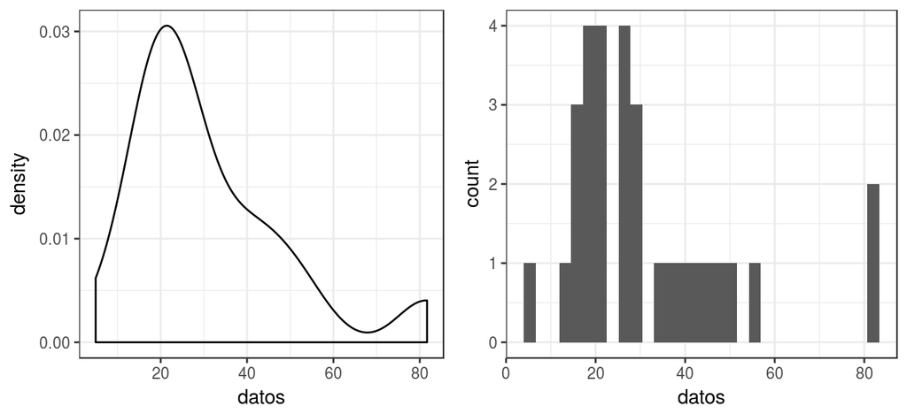

```r
library(ggpubr)

datos <- c(81.372918, 25.700971, 4.942646, 43.020853, 81.690589, 51.195236,
           55.659909, 15.153155, 38.745780, 12.610385, 22.415094, 18.355721,
           38.081501, 48.171135, 18.462725, 44.642251, 25.391082, 20.410874,
           15.778187, 19.351485, 20.189991, 27.795406, 25.268600, 20.177459,
           15.196887, 26.206537, 19.190966, 35.481161, 28.094252, 30.305922)

p1 <- ggplot(data = data_frame(datos), aes(x = datos)) +
      geom_density()  +
      theme_bw()

p2 <- ggplot(data = data_frame(datos), aes(x = datos)) +
      geom_histogram()  +
      theme_bw()

ggarrange(p1, p2)
```

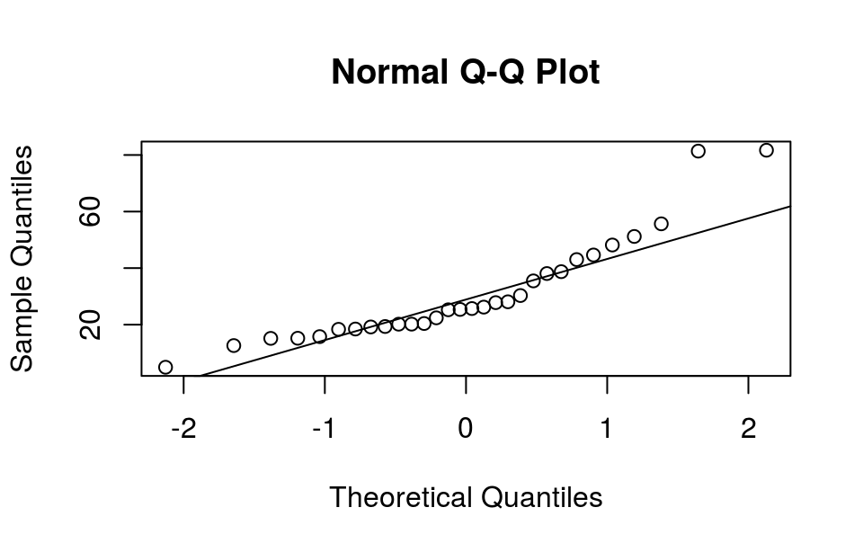

```r
qqnorm(datos)
qqline(datos)
```

```r
shapiro.test(datos)
```

```
##
##  Shapiro-Wilk normality test
##
## data:  datos
## W = 0.85765, p-value = 0.0009003
```

La representación gráfica y el test de normalidad *Shapiro-Wilk* muestran que los datos no se distribuyen de forma normal. Esto implica que la aproximación basada en el teorema del límite central para estimar el error estándar $SE = \frac{sd}{\sqrt{n}}$ deja de ser buena y, por lo tanto, también los intervalos paramétricos basados en la estructura $[parámetro \ estimado \pm t_{\alpha}SE]$ que se generen con esa estimación del $SE$. Una alternativa para poder calcular intervalos de confianza es emplear *Bootstrapping*.

El método de *Bootstrapping* se basa en generar nuevas pseudomuestras del mismo tamaño que la muestra real, realizando muestreo repetido de las observaciones. Si la muestra original es representativa de la población, la distribución del estadístico calculada a partir de las pseudomuestras (*bootstraping distribution*) se asemejará a la distribución muestral que se obtendría si se pudiera acceder a la población para generar nuevas muestras. De tal forma que:

- La *sd* de la *bootstraping distribution* es un estimador del *SE*.
- La media de la *bootstraping distribution* es un estimador del verdadero parámetro poblacional.

Así pues, a partir de la *bootstraping distribution* se pueden obtener los valores necesarios para crear el intervalo de confianza sin recurrir al teorema del límite central.

**Generar la bootstrapping distribution**

```r
boot_distribution <- rep(NA, 9999)
for (i in 1:9999) {
    boot_distribution[i] <- mean(sample(x = datos, size = 30, replace = TRUE))
}
```

**Estudio la bootstrapping distribution**

Dependiendo de la distribución que tengan los estadísticos obtenidos por *bootstraping*, se emplea un método distinto para estimar los límites del intervalo de confianza. Cuando la distribución obtenida no es de tipo normal, no se pueden emplear intervalos de confianza basados en la *t-distribution* ni en percentiles.

Distribución:

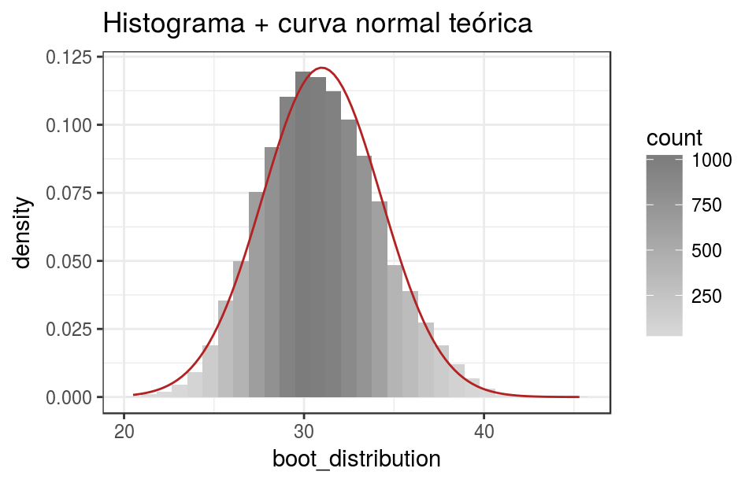

```r
ggplot(data = data.frame(boot_distribution), aes(x = boot_distribution)) +
  geom_histogram(aes(y = ..density.. , fill = ..count..)) +
  scale_fill_gradient(low = "#DCDCDC", high = "#7C7C7C") +
  stat_function(fun = dnorm, colour = "firebrick",
                args = list(mean = mean(boot_distribution),
                            sd = sd(boot_distribution))) +
  ggtitle("Histograma + curva normal teórica") +
  theme_bw()
```

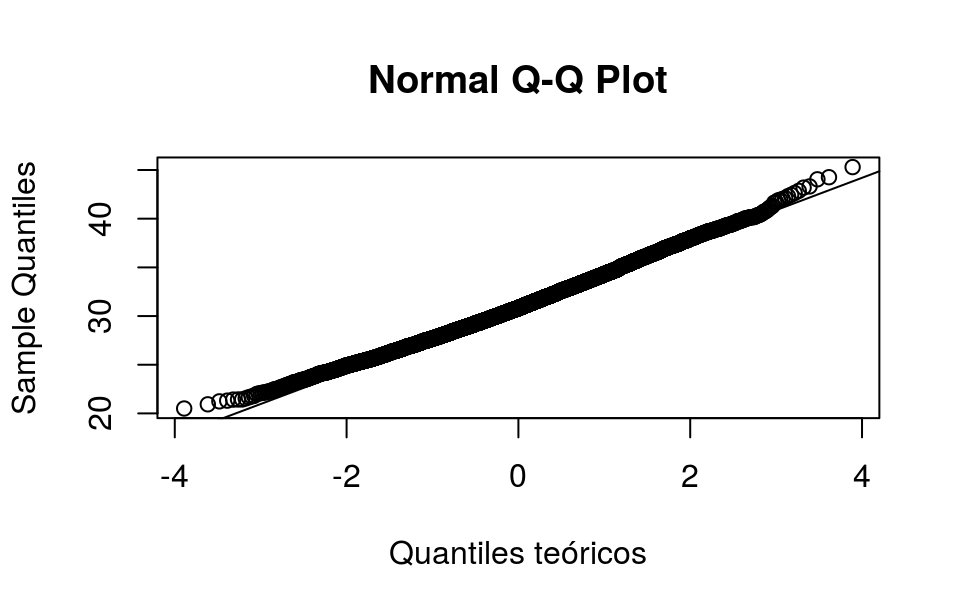

```r
qqnorm(boot_distribution,  xlab = "Quantiles teóricos")
qqline(boot_distribution)
```

La distribución de los estadísticos obtenidos por *bootstraping* se distribuyen de forma normal.

Centro:  
La media de la *bootstraping distribution* debe de ser cercana a la media de la muestra inicial a partir de la cual se está generando el *bootstrapping.* A esta diferencia se le llama *bias*.

```r
mean(datos) - mean(boot_distribution)
```

```
## [1] -0.02038152
```

En este caso el *bias* es muy pequeño comparado al valor de la media calculada.

**Intervalo de confianza**

Existen varios métodos para generar intervalos de confianza a partir de una *bootstrapping distribution*. Los intervalos de tipo *t* y los basados en percentiles emplean la desviación estándar de la *bootstrapping distribution* como estimación del *SE*.

Intervalo basado en *t-distribution*:

$$[parámetro \ estimado \pm t_{\alpha,df}SE]$$

- media = mean(datos) = 30.9686559
- $t_{\alpha = 0.05,df=29}$ = *qt(p=1-0.05/2, df = 29)* = 2.045
- SE = *sd(boot_distribution)* = 3.2972693
- IC 95% = [24.23, 37.71]

Intervalo de confianza basado en percentiles:

```r
# Un IC del 95% debe abarcar desde el percentil 0.025 al 0.975
quantile(x = boot_distribution,probs = c(0.025, 0.975))
```

```
##     2.5%    97.5%
## 25.00433 37.79446
```

Tanto el intervalo basado en el valor *t* como el basado en *percentiles* son únicamente válidos cuando la *bootstrapping distribution* se asemeja a una normal y el *bias* es pequeño. El intervalo basado en percentiles no ignora la asimetría de los datos por lo que se suele considerar más adecuado. En caso de no cumplirse estas condiciones, o de que ambos intervalos no se asemejen entre sí, ninguno es fiable.

El intervalo de confianza más adecuado para *bootstrapping* se conoce como *Intervalo Bootstrapping Bias Corrected Acelerated, BCa*. En `R` existen varios paquetes que permiten obtener la distribución de *bootstrapping* así como el intervalo *BCa*.

**Solución mediante R**

La función `boot()` del paquete `boot` recibe como argumentos un vector con las observaciones, una función que calcule el estadístico de interés (tiene que ser definida previamente por el usuario) y el número de simulaciones.

```r
library(boot)
media <- function(valores, i) {
    mean(valores[i])
}

boot_distribution <- boot(datos, media, R = 9999)
boot_distribution
```

```
##
## ORDINARY NONPARAMETRIC BOOTSTRAP
##
##
## Call:
## boot(data = datos, statistic = media, R = 9999)
##
##
## Bootstrap Statistics :
##     original      bias    std. error
## t1* 30.96866 -0.01574912    3.297201
```

Una vez generado el objeto `boot`, se puede mostrar gráficamente la distribución y calcular los diferentes tipos de intervalos.

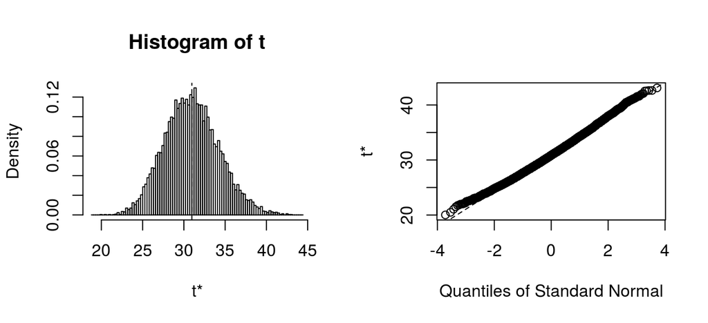

```r
plot(boot_distribution)
```

```r
boot.ci(boot_distribution, conf = 0.95)
```

```
## BOOTSTRAP CONFIDENCE INTERVAL CALCULATIONS
## Based on 9999 bootstrap replicates
##
## CALL :
## boot.ci(boot.out = boot_distribution, conf = 0.95)
##
## Intervals :
## Level      Normal              Basic
## 95%   (24.52, 37.45 )   (24.12, 37.02 )
##
## Level     Percentile            BCa
## 95%   (24.92, 37.82 )   (25.44, 38.68 )
## Calculations and Intervals on Original Scale
```

Otra opción disponible en `R` es la función `bootES()` del paquete `bootES`, que internamente hace una llamada a la función `boot()` pero sin necesidad de definir la función del estadístico.

```r
library(bootES)
bootES(data = datos, R = 9999, mean)
```

[output not shown]

## Ejemplo 2

*Supóngase que se quiere estimar el precio de las viviendas en una ciudad a partir de una muestra de 50 propiedades. ¿Cuál es el intervalo de confianza del 95% del precio de las viviendas de la ciudad?*

```r
precios <- c(142, 175, 198, 150, 705, 232, 50, 146, 155, 1850, 132, 215,117, 245,
             290, 200, 260, 450, 66, 165, 362, 307, 266, 166, 375,245, 211, 265,
             296, 335, 335, 1370, 256, 148, 988, 324, 216, 684,270, 330, 222, 180,
             257, 253, 150, 225, 217, 570, 507, 190)
```

**Exploración de los datos**

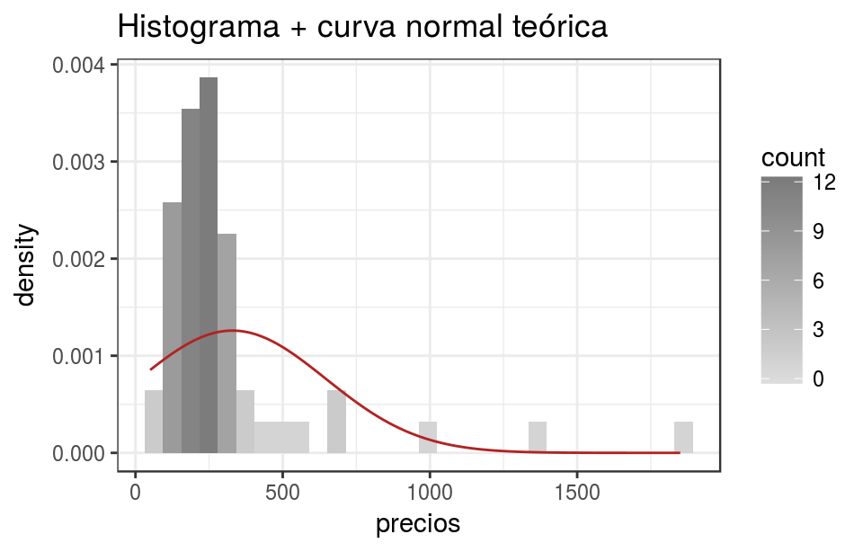

```r
ggplot(data = data.frame(precios), aes(x = precios)) +
  geom_histogram(aes(y = ..density.. , fill = ..count..)) +
  scale_fill_gradient(low = "#DCDCDC", high = "#7C7C7C") +
  stat_function(fun = dnorm, colour = "firebrick",
                args = list(mean = mean(precios),
                            sd = sd(precios))) +
  ggtitle("Histograma + curva normal teórica") +
  theme_bw()
```

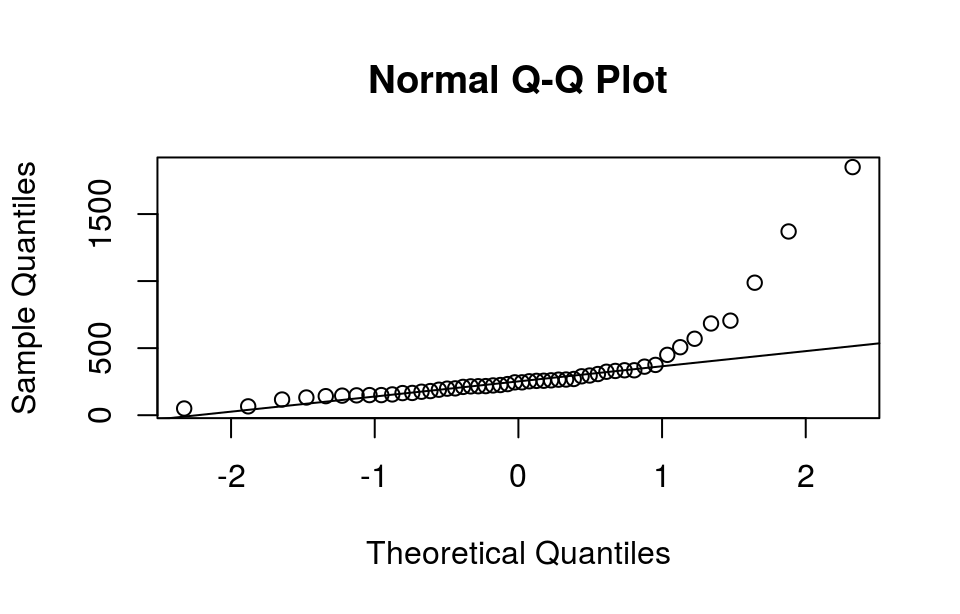

```r
qqnorm(precios)
qqline(precios)
```

La representación gráfica de los datos refleja que la muestra es muy asimétrica.

Si los datos no se distribuyen de forma normal, no se pueden aplicar métodos paramétricos basados en el teorema del límite central. Además, dado que hay asimetría, es recomendable emplear estadísticos más robustos que la media como la mediana o la media truncada (*trimmed mean*). Por lo general, para los métodos de *bootstrapping*, se recomienda la media truncada antes que la mediana.

- 25% media truncada: Se define como la media del 50% de los valores centrales. Es decir, la media de los valores que caen entre el primer y el tercer percentil (lo que forma la caja en los diagramas box-plot). En `R` se calcula mediante `mean(x=, trim= 0.25)`.

La idea de *Bootstrapping* es que, la *bootstrapping distribution*, se debe asemejar a la *sampling distribution* del parámetro estimado (en este caso la trimmed mean). Y que la *sd* de la *bootstrapping distribution* se aproxima al *SE* de la *sampling distribution*. Es decir, mediante *bootstrapping* podemos obtener los valores necesarios para calcular el intervalo de confianza sin recurrir a los métodos teóricos basados en teorema del límite central.

**Cálculo de la bootstraping distribution**

```r
library(boot)
media_truncada <- function(valores, i) {
    mean(valores[i], trim = 0.25)
}
boot_distribution <- boot(precios, media_truncada, R = 9999)
boot_distribution
```

```
##
## ORDINARY NONPARAMETRIC BOOTSTRAP
##
##
## Call:
## boot(data = precios, statistic = media_truncada, R = 9999)
##
##
## Bootstrap Statistics :
##     original    bias    std. error
## t1* 244.0385 0.6874303    17.29494
```

**Estudio de la bootstrapping distribution**

Distribución:

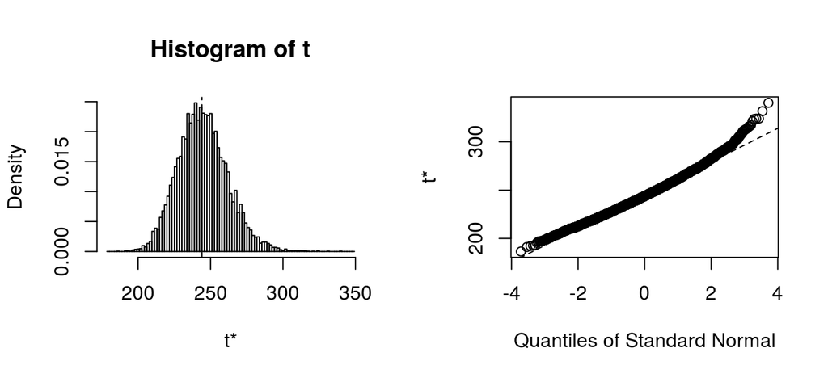

```r
plot(boot_distribution)
```

La distribución generada no cumple las condiciones de normalidad. Esto implica que los intervalos de confianza obtenidos por percentiles o basados en la t-distribution no son fiables, es más precisa la estimación obtenida por los intervalos *BCa*.

Centro:

La media de la *bootstrapping distribution* debe de ser cercana al valor del estadístico estudiado en la muestra inicial a partir de la cual se está generando el *bootstrapping*. A esta diferencia se le llama *bias*.

```r
mean(precios, trim = 0.25) - mean(boot_distribution$t)
```

```
## [1] -0.6874303
```

**Intervalo de confianza**

```r
boot.ci(boot_distribution)
```

```
## BOOTSTRAP CONFIDENCE INTERVAL CALCULATIONS
## Based on 9999 bootstrap replicates
##
## CALL :
## boot.ci(boot.out = boot_distribution)
##
## Intervals :
## Level      Normal              Basic
## 95%   (209.5, 277.2 )   (206.6, 274.9 )
##
## Level     Percentile            BCa
## 95%   (213.2, 281.5 )   (213.9, 282.4 )
## Calculations and Intervals on Original Scale
```

# Bootstrapping para cálculo de *p-value*.

El *Bootstrapping*, como test de significancia para la diferencia entre grupos, se emplea cuando se quiere estudiar si la diferencia entre dos poblaciones es significativa, empleando muestras aleatorias y separadas de cada una de las poblaciones.

## Ejemplo1

*Un estudio pretende determinar si existe diferencia entre el promedio de los logros académicos de los estudiantes inmigrantes procedentes de México y los procedentes de otros países latinoamericanos. Para ello, se obtiene una muestra aleatoria de estudiantes que llegaron al país entre 2005 y 2006 entre los que hay mexicanos y no mexicanos (otros paises).*

Ejemplo obtenido del libro *Comparing Groups Randomization and Bootstrap Methods Using R*. Los datos ya no están disponibles en la página web del libro, pero puede encontrarse en [Github](https://github.com/JoaquinAmatRodrigo/Estadistica-con-R/tree/master/datos).

Dado que se trata de un diseño muestral, en el que se ha obtenido una muestra aleatoria con individuos de cada uno de los grupos que se van a comparar, el método adecuado es *bootstrapping*.

**Exploración de datos**

```r
datos <- read_csv("./datos/LatinoEd.csv")
datos <- datos %>% select(Achieve, Mex)
datos <- datos %>% rename(nota = Achieve, nacionalidad = Mex)
datos <- datos %>% mutate(nacionalidad = recode(nacionalidad,
                                                `1` = "mexicana",
                                                `0` = "otras"))
head(datos)
```

```
## # A tibble: 6 x 2
##    nota nacionalidad
##   <dbl> <chr>
## 1  59.2 mexicana
## 2  63.7 mexicana
## 3  62.4 mexicana
## 4  46.8 mexicana
## 5  67.6 mexicana
## 6  63.1 otras
```

El promedio del rendimiento académico es de 5.92 puntos menor en estudiantes de origen mexicano que el de otras nacionalidades latinas.

```r
datos %>% group_by(nacionalidad) %>% summarise(media = mean(nota),
                                               mediana = median(nota),
                                               sd = sd(nota),
                                               n = n())
```

```
## # A tibble: 2 x 5
##   nacionalidad media mediana    sd     n
##   <chr>        <dbl>   <dbl> <dbl> <int>
## 1 mexicana      58.6    60.8  15.6   116
## 2 otras         64.5    66.6  13.0    34
```

```r
mean_mexicana <- datos %>% filter(nacionalidad == "mexicana") %>%
                           pull(nota) %>%
                           mean()
mean_otras <- datos %>% filter(nacionalidad == "otras") %>%
                           pull(nota) %>%
                           mean()
dif_obs <- mean_mexicana - mean_otras
dif_obs
```

```
## [1] -5.921602
```

La exploración gráfica de los datos indica posibles diferencias en la posición de la distribución.

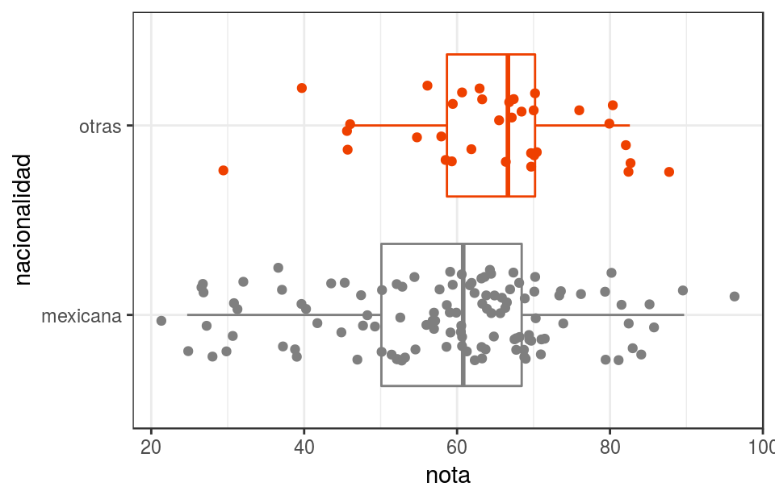

```r
ggplot(data = datos, aes(x = nacionalidad, y = nota, colour = nacionalidad)) +
    geom_boxplot(outlier.shape = NA) +
    geom_jitter(width = 0.25) +
    scale_color_manual(values = c("gray50", "orangered2")) +
    coord_flip() +
    theme_bw() +
    theme(legend.position = "none")
```

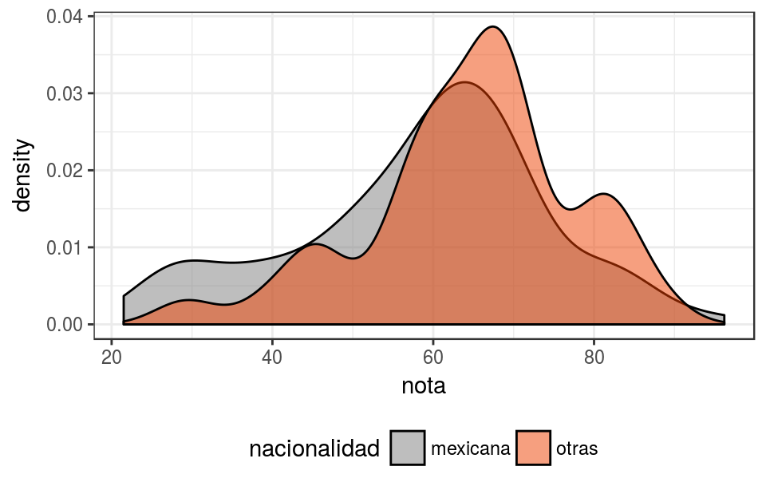

```r
ggplot(data = datos, aes(x = nota, fill = nacionalidad)) +
    geom_density(alpha = 0.5) +
    scale_fill_manual(values = c("gray50", "orangered2")) +
    theme_bw() +
    theme(legend.position = "bottom")
```

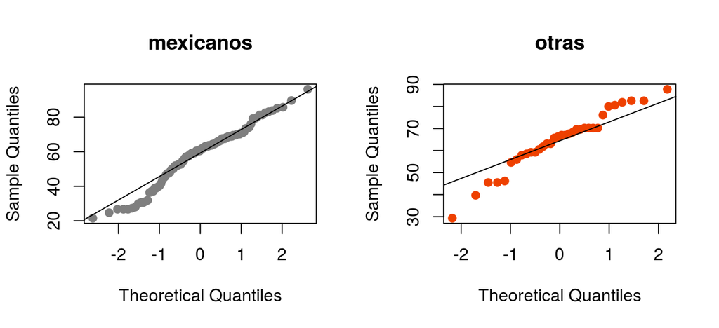

```r
par(mfrow = c(1, 2))
qqnorm(filter(datos, nacionalidad == "mexicana") %>% pull(nota),
       main = "mexicanos", col = "gray50", pch = 19)
qqline(filter(datos, nacionalidad == "mexicana") %>% pull(nota))

qqnorm(filter(datos, nacionalidad == "otras") %>% pull(nota),
       main = "otras", col = "orangered2", pch = 19)
qqline(filter(datos, nacionalidad == "otras") %>% pull(nota))
```

```r
par(mfrow =  c(1,1))
```

Los datos no se distribuyen de forma normal, siendo más marcada la falta de normalidad en las observaciones de nacionalidad no mexicana, que es la muestra de menor tamaño.

**Distribución bootstrapping**

Mediante *bootstrapping* se generan nuevas pseudomuestras de individuos empleando las dos muestras originales (mexicanos y no mexicanos) combinadas. Con cada una de las pseudomuestras, se generan dos grupos de tamaños iguales a los grupos de las muestras originales (34, 116) y se calcula la diferencia del estadístico, en este caso la media. El proceso se asemeja mucho al empleado en los test de permutación. La diferencia radica en que en los test de permutación, se emplean siempre las observaciones de la muestra original ordenadas de forma distinta en cada iteración. En este caso, en cada iteración y antes del reparto en grupos, se genera una nueva pseudomuestra que tiene el mismo tamaño que la muestra original pero formada por distintas observaciones.

```r
boot_distribution <- rep(NA, 9999)
n_mexicana <- datos %>% filter(nacionalidad == "mexicana") %>% nrow()
n_otras <- datos %>% filter(nacionalidad == "otras") %>% nrow()

for (i in 1:9999) {
  # Se crea un paseudomuestra
  pseudomuestra <- sample(datos$nota, size = length(datos$nota), replace = TRUE)
  # Se reparten las observaciones en dos grupos y se calculan las medias
  mean_mexicana <- mean(pseudomuestra[1:n_mexicana])
  mean_otras    <- mean(pseudomuestra[(n_mexicana + 1):length(pseudomuestra)])
  # Se calcula la diferencia de medias
  boot_distribution[i] <- mean_mexicana - mean_otras
}
```

Los datos simulados forman lo que se conoce como *bootstrapping distribution* y representa la variación esperada en la diferencia de medias debida únicamente al muestreo aleatorio.

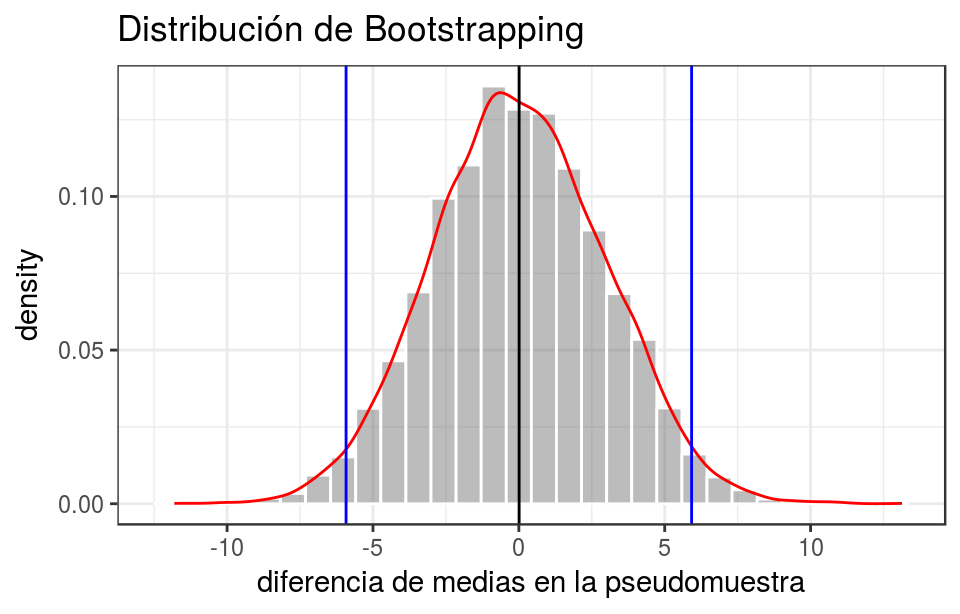

```r
ggplot(data = data.frame(boot_distribution), aes(boot_distribution)) +
  geom_histogram(aes(y = ..density..), alpha = 0.4, colour = "white") +
  geom_line(aes(y = ..density..), stat = 'density', colour = "red") +
  geom_vline(xintercept = mean(boot_distribution)) +
  geom_vline(xintercept = dif_obs, colour = "blue") +
  geom_vline(xintercept = -dif_obs, colour = "blue") +
  labs(title = "Distribución de Bootstrapping",
       x = "diferencia de medias en la pseudomuestra") +
  theme_bw()
```

```r
summary(boot_distribution)
```

```
##      Min.   1st Qu.    Median      Mean   3rd Qu.      Max.
## -11.80608  -2.02695  -0.04462   0.00997   2.00000  13.13438
```

```r
sd(boot_distribution)
```

```
## [1] 2.959137
```

Como era de esperar, la diferencia entre la media de los grupos considerando que todos proceden de una misma población está centrada en cero. La desviación típica de la *bootsrapping distribution* indica que la variabilidad en la diferencia de medias debida al muestreo, en este caso es de 2.959 unidades.

**Cálculo de p-value**

Finalmente, se calcula la probabilidad (*p-value*) de obtener diferencias igual o más extremas que la observada (líneas verticales azules) con y sin corrección de continuidad.

```r
# Sin corrección
p_value = (sum(abs(boot_distribution) > abs(dif_obs)))/9999
p_value
```

```
## [1] 0.04330433
```

```r
# Con corrección
p_value_corregido = ((sum(abs(boot_distribution) > abs(dif_obs))) + 1)/(9999 + 1)
p_value_corregido
```

```
## [1] 0.0434
```

**Conclusión**

Un test de *bootstrapping* no paramétrico se empleó para determinar si existe diferencia en el promedio de logros académicos entre inmigrantes mexicanos y no mexicanos. Los datos se obtuvieron mediante muestreo aleatorio asegurando así la independencia de los datos. El *p-value* se calculó mediante 9999 simulaciones de Monte Carlo, empleando la corrección de continuidad sugerida por Davison y Hinkley (1997) resultando en 0.043. Esta es una evidencia moderada en contra de la hipótesis nula de que no hay diferencia entre poblaciones y sugiere que los logros académicos entre inmigrantes de nacionalidad mexicana y no mexicana son distintos.

# Boostraping para intervalos de confianza de la diferencia entre poblaciones

Los test de hipótesis que contrastan la diferencia entre dos poblaciones generan un *p-value* basado en la hipótesis nula de que no existe diferencia del estadístico (media, mediana…) entre las poblaciones. Por esta razón, cuando el *bootstrapping* se emplea como test de hipótesis, las observaciones se mezclan dotas juntas y, posteriormente, se generan las pseudomuestras. Cuando la finalidad del estudio es generar intervalos de confianza para la verdadera diferencia de un estadístico entre dos poblaciones, la hipótesis nula considera que las muestras sí proceden de dos poblaciones diferentes, cada una con un valor distinto para el estadístico estudiado. Para simular esta hipótesis nula, las pseudomuestras obtenidas por *sampling with replacement* se tienen que generar de forma separada para cada grupo. Esta es la diferencia entre el empleo de *bootstrapping* para calcular *p-values* y para calcular intervalos de confianza.

El algoritmo del *bootstrapping* para calcular intervalos de confianza de la diferencia entre dos poblaciones es:

1. Generar una nueva pseudomuestra del grupo A del mismo tamaño que la muestra original $n_A$ y empleando únicamente las observaciones pertenecientes a dicho grupo.
2. Generar una nueva pseudomuestra del grupo B del mismo tamaño que la muestra original $n_B$ y empleando únicamente las observaciones pertenecientes a dicho grupo.
3. Calcular la diferencia del estadístico entre las dos nuevas pseudomuestras.
4. Repetir los pasos 1,2 y 3 múltiples veces, almacenando la diferencia calculada en cada iteración. El conjunto de valores generado forma lo que se conoce como la *bootstap distribution* de la diferencia del estadístico si ambas muestras proceden de dos poblaciones distintas. Esta distribución tiende a estar centrada en el verdadero valor de la diferencia entre ambas poblaciones.
5. A partir de la *bootstap distribution*, generar un intervalo de confianza para el parámetro poblacional. Las mismas consideraciones explicadas para intervalos de confianza en una única población se aplican también a la diferencia entre poblaciones.

## Tamaño del efecto (effect size)

El cálculo de *p-value* y los intervalos de confianza permiten responder a dos de las preguntas fundamentales cuando se comparan poblaciones:

- ¿Existen evidencias que apunten a la existencia de una diferencia real entre las dos poblaciones? o ¿Es la diferencia observada la esperada por simple variabilidad?
- ¿Si el la diferencia es real, cómo de grande es esta diferencia?

A pesar de la importancia de estas dos preguntas, existe una tercera que es fundamental a la hora de tomar decisiones en base a los resultados. ¿Es la diferencia suficientemente grande como para ser práctica? Cuando las unidades en la que se expresa la diferencia son familiares para el analista, se pueden interpretar fácilmente. Sin embargo, en muchas ocasiones, la escala en la que se mide la diferencia no es intuitiva, lo que complica su interpretación así como su divulgación. Por esta razón siempre se debe reportar la diferencia obtenida en unidades estandarizadas, lo que se conoce como tamaño de efecto o *effect size*. Uno de los tamaños de efecto más empleados es la $Cohen's \ d$, que consiste en expresar la diferencia entre las medias en términos de desviación típica (*pooled sd*).

## Ejemplo 1

*Empleando los datos del estudio de logros académicos entre inmigrantes de nacionalidad mexicana y no mexicana, generar un intervalo de confianza de la diferencia en la media de rendimiento académico entre ambas poblaciones.*

```r
datos <- read_csv("./datos/LatinoEd.csv")
datos <- as.data.frame(datos)
datos <- datos %>% select(Achieve, Mex)
datos <- datos %>% rename(nota = Achieve, nacionalidad = Mex)
datos <- datos %>% mutate(nacionalidad = recode(nacionalidad,
                                                `1` = "mexicana",
                                                `0` = "otras"))
head(datos)
```

```
##   nota nacionalidad
## 1 59.2     mexicana
## 2 63.7     mexicana
## 3 62.4     mexicana
## 4 46.8     mexicana
## 5 67.6     mexicana
## 6 63.1        otras
```

```r
datos %>% group_by(nacionalidad) %>% summarise(media = mean(nota),
                                               mediana = median(nota),
                                               sd = sd(nota),
                                               n = n())
```

```
## # A tibble: 2 x 5
##   nacionalidad media mediana    sd     n
##   <chr>        <dbl>   <dbl> <dbl> <int>
## 1 mexicana      58.6    60.8  15.6   116
## 2 otras         64.5    66.6  13.0    34
```

```r
mean_mexicana <- datos %>% filter(nacionalidad == "mexicana") %>%
                           pull(nota) %>%
                           mean()
mean_otras <- datos %>% filter(nacionalidad == "otras") %>%
                           pull(nota) %>%
                           mean()
dif_obs <- mean_mexicana - mean_otras
dif_obs
```

```
## [1] -5.921602
```

Se emplean las dos funciones de `R` que automatizan el proceso de *resampling* teniendo en cuenta cada grupo:

**Función boot()**

Esta función requiere que se defina previamente la función que calcula el estadístico de interés, en este caso la media.

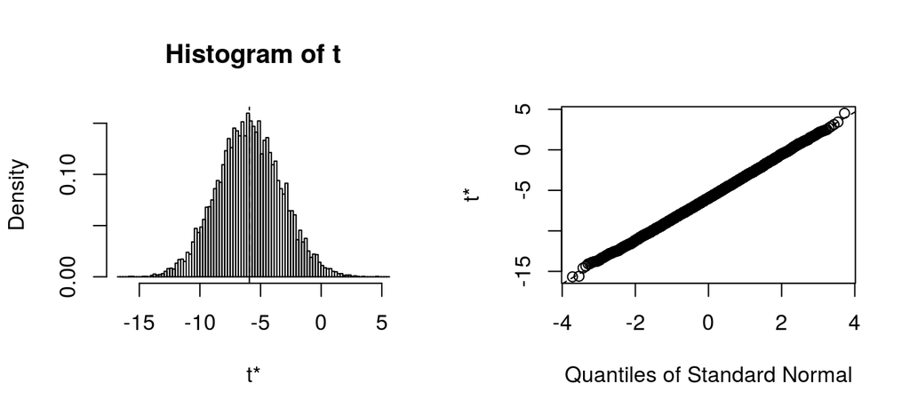

```r
library(boot)

#Función que calcula la diferencia entre medias de los dos grupos
diferencia_medias <- function(data, i) {
  pseudomuestra <- data[i,]
  mean_mexicana <- mean(pseudomuestra[pseudomuestra$nacionalidad == "mexicana", "nota"])
  mean_otras <- mean(pseudomuestra[pseudomuestra$nacionalidad == "otras", "nota"])
  return(mean_mexicana - mean_otras)
}


#El argumento strata de la funcion boot() permite identificar los grupos
set.seed(5290)
boot_distribution <- boot(data = datos, statistic = diferencia_medias, R = 9999,
                          strata = as.factor(datos$nacionalidad))
plot(boot_distribution)
```

```r
boot_distribution
```

```
##
## STRATIFIED BOOTSTRAP
##
##
## Call:
## boot(data = datos, statistic = diferencia_medias, R = 9999, strata = as.factor(datos$nacionalidad))
##
##
## Bootstrap Statistics :
##      original      bias    std. error
## t1* -5.921602 -0.01208596    2.648277
```

```r
boot.ci(boot_distribution)
```

```
## BOOTSTRAP CONFIDENCE INTERVAL CALCULATIONS
## Based on 9999 bootstrap replicates
##
## CALL :
## boot.ci(boot.out = boot_distribution)
##
## Intervals :
## Level      Normal              Basic
## 95%   (-11.100,  -0.719 )   (-11.209,  -0.773 )
##
## Level     Percentile            BCa
## 95%   (-11.071,  -0.634 )   (-11.044,  -0.614 )
## Calculations and Intervals on Original Scale
```

**Funcion bootES()**

La función `bootES()` hace una llamada interna a `boot()` pero facilita la sintaxis al no necesitar definir la función del estadístico cando ya existen en `R` (mean, median…).

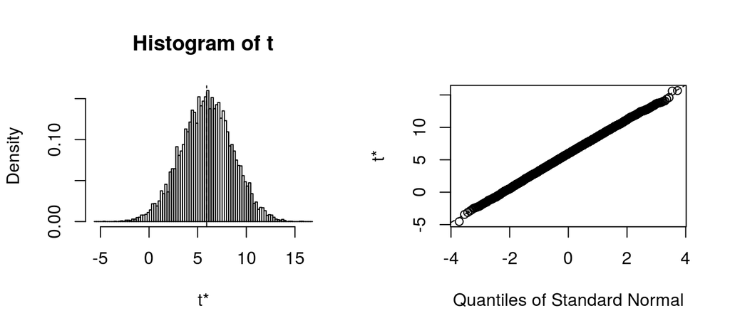

```
##
## User-specified lambdas: (mexicana, otras)
## Scaled lambdas: (-1, 1)
## 95.00% bca Confidence Interval, 9999 replicates
## Stat        CI (Low)    CI (High)   bias        SE
## 5.922       0.614       11.044      0.012       2.648
```

```r
require(bootES)
set.seed(5290)
bootES(data = datos, data.col = "nota", group.col = "nacionalidad",
       contrast = c("mexicana", "otras"), R = 9999, plot = TRUE)
```

La distribución generada está centrada en el valor de la diferencia observada (-5.9), ya que el *resampling* se está haciendo acorde a la hipótesis nula de que las muestras proceden de poblaciones distintas. Además, como la distribución obtenida cumple la normalidad, todos los diferentes tipos de intervalos (percentiles, t, BCa) se consideran válidos.

**Tamaño del efecto**

La función `bootES()` permite, además de generar los intervalos de confianza para la diferencia de dos medias en las unidades en las que se está midiendo la variable, calcular intervalos para múltiples tipos de tamaño de efecto. *Se puede encontrar una descripción detallada de todos ellos en BootES: An R package for bootstrap confidence intervals on effect sizes (Kris N.Kirby & Daniel Gerlanc).*

```r
require(bootES)
bootES(data = datos, data.col = "nota", group.col = "nacionalidad",
       contrast = c("mexicana", "otras"), R = 9999,
       effect.type = "cohens.d")
```

```
##
## User-specified lambdas: (mexicana, otras)
## Scaled lambdas: (-1, 1)
## 95.00% bca Confidence Interval, 9999 replicates
## Stat        CI (Low)    CI (High)   bias        SE
## 0.392       0.027       0.721       0.003       0.175
```

Acorde al resultado devuelto por `bootES()`, el tamaño de efecto es de *0.392* y su CI del 95% (*0.03*, *0.722*). Este valor sugiere que la diferencia observada en las notas aunque significativa, es pequeña.

## Ejemplo 2

*Se dispone de un set de datos con información sobre el tiempo que una empresa de telefonía tarda en reparar los problemas que tienen dos grupos de consumidores (CLEC y ILEC). Se desea conocer cuál es la diferencia en la media los tiempos de reparación de ambos grupos empleando un intervalo de confianza del 95%.*

```r
require("resample")
data("Verizon")
head(Verizon)
```

```
##    Time Group
## 1 17.50  ILEC
## 2  2.40  ILEC
## 3  0.00  ILEC
## 4  0.65  ILEC
## 5 22.23  ILEC
## 6  1.20  ILEC
```

**Exploración de los datos**

```r
Verizon %>% group_by(Group) %>% summarise(media = mean(Time),
                                          median = median(Time),
                                          sd = sd(Time),
                                          n = n())
```

```
## # A tibble: 2 x 5
##   Group media median    sd     n
##   <fct> <dbl>  <dbl> <dbl> <int>
## 1 CLEC  16.5   14.3   19.5    23
## 2 ILEC   8.41   3.59  14.7  1664
```

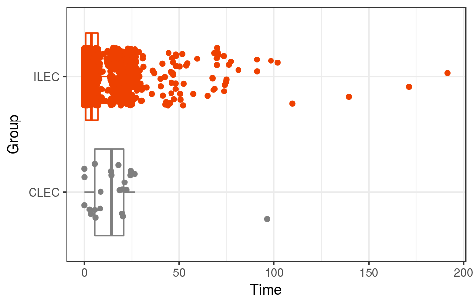

```r
ggplot(data = Verizon, aes(x = Group, y = Time, colour = Group)) +
  geom_boxplot(outlier.shape = NA) +
  geom_jitter(width = 0.25) +
  scale_color_manual(values = c("gray50", "orangered2")) +
  coord_flip() +
  theme_bw() +
  theme(legend.position = "none")
```

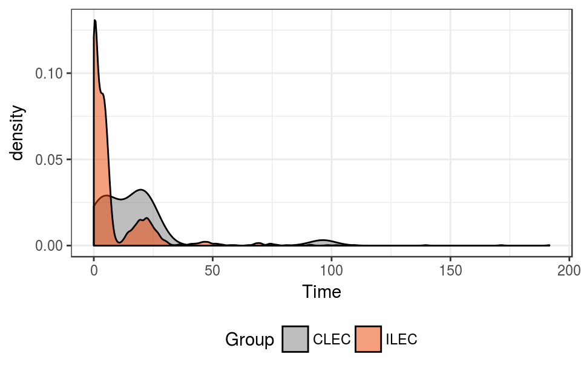

```r
ggplot(data = Verizon, aes(x = Time, fill = Group)) +
  geom_density(alpha = 0.5) +
  scale_fill_manual(values = c("gray50", "orangered2")) +
  theme_bw() +
  theme(legend.position = "bottom")
```

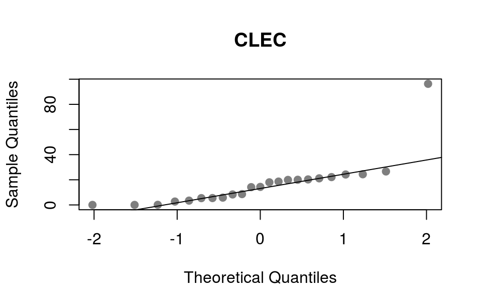

```r
qqnorm(Verizon[Verizon$Group == "CLEC", "Time"], col = "gray50", pch = 19,
       main = "CLEC" )
qqline(Verizon[Verizon$Group == "CLEC", "Time"])
```

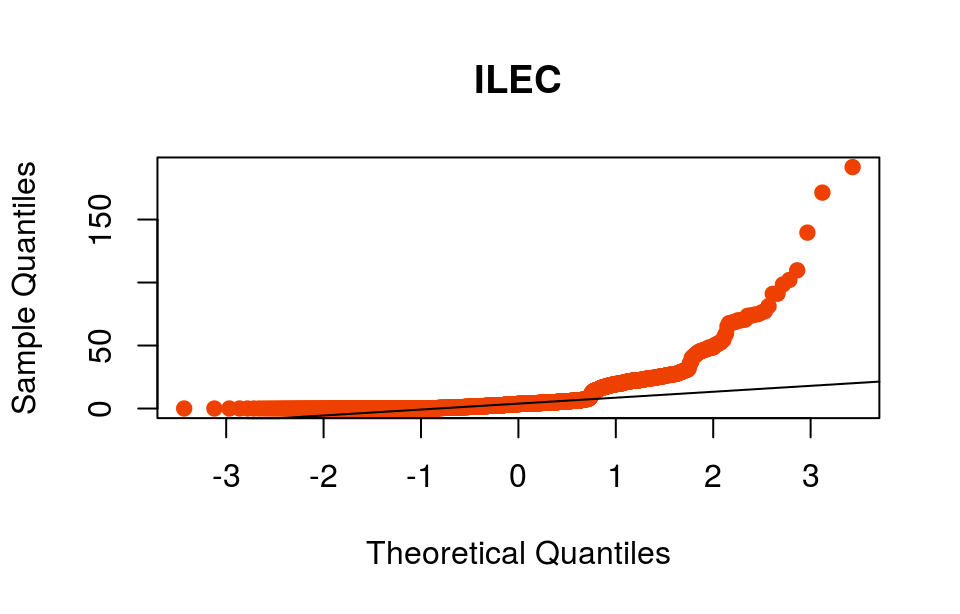

```r
qqnorm(Verizon[Verizon$Group == "ILEC", "Time"], col = "orangered2", pch = 19,
       main = "ILEC" )
qqline(Verizon[Verizon$Group == "ILEC", "Time"])
```

La representación gráfica muestra una marcada asimetría de los datos. Además, el tamaño de uno de los grupos de solo 23 observaciones.

Los métodos paramétricos basados en el teorema del límite central, tales como los *t-test*, emplean como Error Estándar la ecuación $SE = \sqrt{\frac{sd_1^2}{n_1} + \frac{sd_2^2}{n_2}}$. Cuando las condiciones de normalidad no se cumplen, está aproximación no es válida. El *bootstrapping* permite obtener el valor de *SE* sin tener que recurrir al teorema del límite central, ya que, la desviación estándar de la *bootstrapping distribution* se aproxima al *SE* de la *sampling distribution*.

**Cálculo de la bootstrapping distribution**

Se obtienen nuevas pseudomuestras por separado de cada una de las muestras iniciales manteniendo el tamaño original y se calcula la diferencia.

```r
boot_distribution <- rep(NA, 9999)
ILEC <- Verizon %>% filter(Group == "ILEC") %>% pull(Time)
CLEC <- Verizon %>% filter(Group == "CLEC") %>% pull(Time)

for (i in 1:9999) {
    boot_ILEC <- sample(x = ILEC, size = length(ILEC), replace = TRUE)
    boot_CLEC <- sample(x = ILEC, size = length(ILEC), replace = TRUE)
    boot_distribution[i] <- mean(boot_ILEC) - mean(boot_CLEC)
}
```

Con la función `bootES()` se puede realizar el mismo proceso de forma más eficiente.

```r
require(bootES)
set.seed(5290)
boot_distribution <- bootES(data = Verizon, data.col = "Time", group.col = "Group",
                            contrast = c("CLEC", "ILEC"), R = 9999)
```

**Estudio la bootstrapping distribution**

```r
mean(boot_distribution$t)
```

```
## [1] -8.142566
```

```r
sd(boot_distribution$t)
```

```
## [1] 4.029708
```

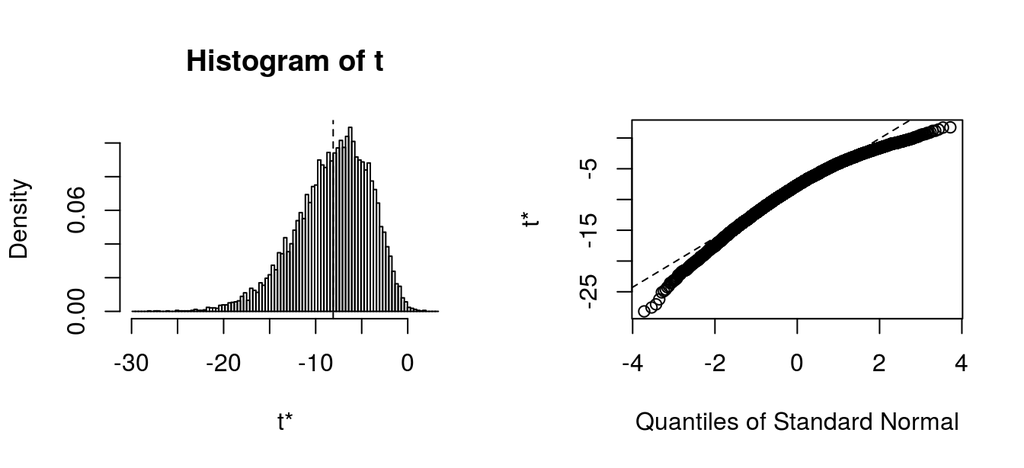

```r
plot(boot_distribution)
```

Dado que la distribución obtenida por *bootstrapping* no es normal, los intervalos basados en *t-distribution* o percentiles no son adecuados, solo el de tipo *BCa*.

**Intervalo de confianza**

```r
# Intervalo de confianza obtenido por bca
boot_distribution
```

```
##
## User-specified lambdas: (CLEC, ILEC)
## Scaled lambdas: (-1, 1)
## 95.00% bca Confidence Interval, 9999 replicates
## Stat        CI (Low)     CI (High)   bias        SE
## -8.098      -17.923      -1.996      -0.045      4.030
```

**Tamaño del efecto**

```r
set.seed(5290)
bootES(data = Verizon, data.col = "Time", group.col = "Group",
       contrast = c("CLEC", "ILEC"), effect.type = "cohens.d",
       R = 9999)
```

```
##
## User-specified lambdas: (CLEC, ILEC)
## Scaled lambdas: (-1, 1)
## 95.00% bca Confidence Interval, 9999 replicates
## Stat        CI (Low)    CI (High)   bias        SE
## -0.549      -1.168      -0.110      -0.007      0.276
```

**Conclusión**

Sí existen evidencias significativas para afirmar que el tiempo promedio de reparación entre los dos grupos es distinto. El intervalo de confianza del 95% para la diferencia de medias obtenido por *bootstrapping* indica que, en promedio, las reparaciones del grupo *CLEC* tardan de *17.923* a *1.996* horas más.

# Bootstrapping para datos pareados

*Un determinado estudio pretende determinar si existe relación entre la luna llena y la agresividad de las personas dementes. Para ello, se mide con un test de comportamiento el nivel de agresividad de 15 pacientes los días de luna llena y los días sin luna llena. Obtener el intervalo de confianza del 95% para la verdadera diferencia entre las dos condiciones.*

Dado que se trata de un diseño muestral, el método adecuado es el *bootstrapping*.

```r
datos <- data.frame(paciente = c(1:15),
                    luna_llena = c(3.33, 3.67, 2.67, 3.33, 3.33, 3.67, 4.67, 2.67,
                                   6, 4.33, 3.33, 0.67, 1.33, 0.33, 2),
                    sin_luna = c(0.27, 0.59, 0.32, 0.19, 1.26, 0.11, 0.30, 0.4,
                                 1.59, 0.6, 0.65, 0.69, 1.26, 0.23,0.38))
head(datos)
```

```
##   paciente luna_llena sin_luna
## 1        1       3.33     0.27
## 2        2       3.67     0.59
## 3        3       2.67     0.32
## 4        4       3.33     0.19
## 5        5       3.33     1.26
## 6        6       3.67     0.11
```

```r
mean(datos$luna_llena)
```

```
## [1] 3.022
```

```r
mean(datos$sin_luna)
```

```
## [1] 0.5893333
```

```r
dif_obs <- mean(datos$luna_llena) - mean(datos$sin_luna)
dif_obs
```

```
## [1] 2.432667
```

Cuando se quiere emplear *bootstrapping* para estudiar la diferencia en el promedio de una variable bajo dos condiciones y los datos son pareados, al igual que en un *t-test*, se calcula una nueva variable a partir de la diferencia entre las dos condiciones para cada sujeto.

```r
datos$diff <- datos$luna_llena - datos$sin_luna
head(datos)
```

```
##   paciente luna_llena sin_luna diff
## 1        1       3.33     0.27 3.06
## 2        2       3.67     0.59 3.08
## 3        3       2.67     0.32 2.35
## 4        4       3.33     0.19 3.14
## 5        5       3.33     1.26 2.07
## 6        6       3.67     0.11 3.56
```

Una vez se dispone de esta nueva variable, el proceso es igual al seguido cuando se quiere realizar inferencia sobre el parámetro de una población (*Boostraping para intervalos de confianza de una población*).

**Obtención de la distribución de bootstrapping**

```r
# Utilizando la función boot()
require(boot)
media <- function(valores,i){
    mean(valores[i])
}

set.seed(5290)
boot_distribution <- boot(datos$diff, media, R = 9999)
boot_distribution
```

```
##
## ORDINARY NONPARAMETRIC BOOTSTRAP
##
##
## Call:
## boot(data = datos$diff, statistic = media, R = 9999)
##
##
## Bootstrap Statistics :
##     original      bias    std. error
## t1* 2.432667 0.004540854   0.3674775
```

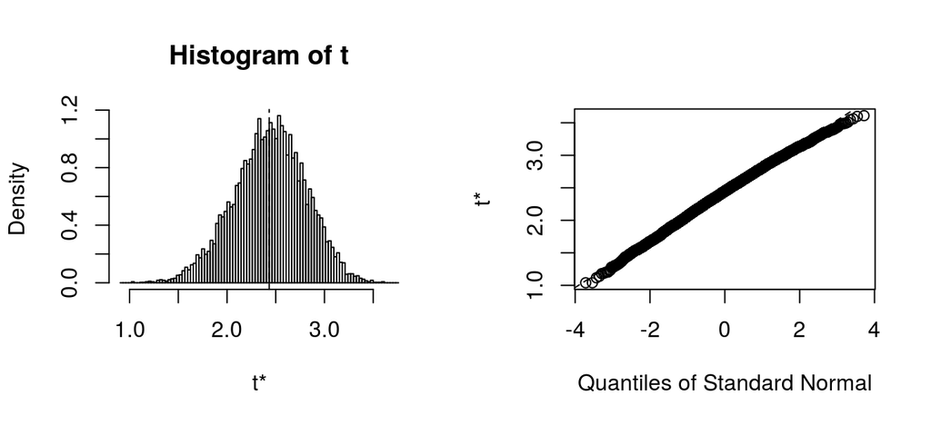

```r
plot(boot_distribution)
```

```r
boot.ci(boot_distribution)
```

```
## BOOTSTRAP CONFIDENCE INTERVAL CALCULATIONS
## Based on 9999 bootstrap replicates
##
## CALL :
## boot.ci(boot.out = boot_distribution)
##
## Intervals :
## Level      Normal              Basic
## 95%   ( 1.708,  3.148 )   ( 1.738,  3.177 )
##
## Level     Percentile            BCa
## 95%   ( 1.688,  3.127 )   ( 1.619,  3.073 )
## Calculations and Intervals on Original Scale
```

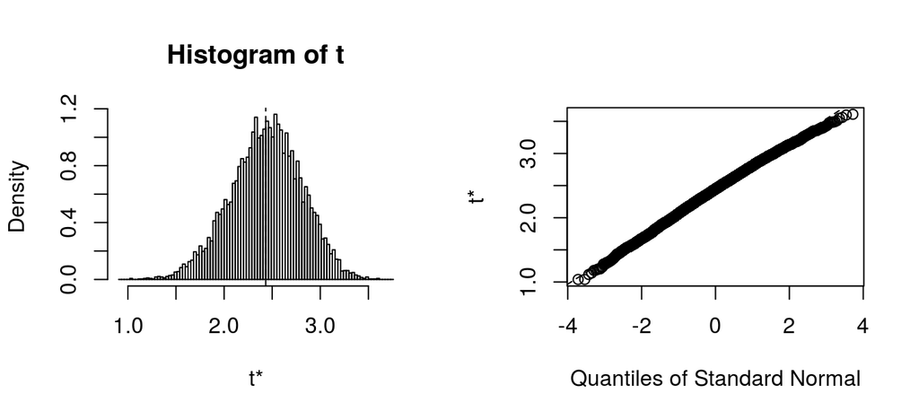

```
##
## 95.00% bca Confidence Interval, 9999 replicates
## Stat        CI (Low)    CI (High)   bias        SE
## 2.433       1.619       3.073       0.005       0.367
```

```r
# Utilizando la función bootES()
set.seed(5290)
bootES(datos$diff, R = 9999, plot = TRUE)
```

Dado que el intervalo de confianza no contiene el valor 0, sí existe evidencia para un alpha de 0.05 de que el promedio de agresividad no es igual con y sin luna llena.

**Tamaño del efecto**

```r
set.seed(5290)
bootES(datos$diff, R = 9999, effect.type = "cohens.d")
```

```
##
## 95.00% bca Confidence Interval, 9999 replicates
## Stat        CI (Low)    CI (High)   bias        SE
## 1.666       0.947       2.707       0.164       0.571
```

# Bootstrapping para coeficientes de correlación

Cuando se estudia la correlación entre dos variables continuas, junto con el valor *R* de la correlación, hay que calcular su intervalo de confianza o su significancia. Por muy alto que sea un coeficiente de correlación, si no es significativo, se tiene que considerar como inexistente puesto que podría deberse simplemente al azar.

*Supongase que se quiere saber si existe una relación entre el salario de los jugadores y su calidad (éxito al batear la pelota). Se dispone de una muestra de 50 jugadores seleccionados al azar de la liga. ¿Se puede considerar real la relación, en caso de que exista?*

```r
jugador = c("Matt_Williams", "Jim_Thome", "Jim_Edmonds", "Fred_McGriff",
            "Jermaine_Dye", "Edgar_Martinez", "Jeff_Cirillo", "Rey_Ordonez",
            "Edgardo_AlfonzoMoises_Alou", "Travis_Fryman", "Kevin_Young",
            "M._GrudzielanekTony_Batista", "Fernando_Tatis", "Doug_Glanville",
            "Miguel_Tejada", "Bill_Mueller", "Mark_McLemore", "Vinny_Castilla",
            "Brook_Fordyce", "Torii_Hunter", "Michael_Tucker", "Eric_Chavez",
            "Aaron_Boone", "Greg_Colbrunn", "Dave_Martinez", "Einar_Diaz",
            "Brian_L._HunterDavid_Ortiz", "Luis_Alicea", "Ron_Coomer",
            "Enrique_Wilson", "Dave_Hansen", "Alfonso_SorianoKeith_Lockhart",
            "Mike_Mordecai", "Julio_Lugo", "Mark_L._JohnsonJason_LaRue",
            "Doug_MientkiewiczJay_Gibbons", "Corey_PattersonFelipe_Lopez",
            "Nick_Johnson", "Thomas_Wilson", "Dave_Roberts", "Pablo_Ozuna",
            "Alexis_Sanchez", "Abraham_Nunez","Corey_PattersonFelipe_Lopez",
            "Nick_Johnson", "Thomas_Wilson", "Dave_Roberts", "Pablo_Ozuna",
            "Alexis_Sanchez", "Abraham_Nunez")
salario = c(9500000, 8000000, 7333333, 7250000, 7166667, 7086668, 6375000, 6250000,
            6200000, 6000000, 5825000, 5625000, 5000000, 4900000, 4500000, 4000000,
            3625000, 3450000, 3150000, 3000000, 2500000, 2400000, 2250000, 2125000,
            2100000, 1800000, 1500000, 1087500, 1000000, 950000, 800000, 750000,
            720000, 675000, 630000, 600000, 500000, 325000, 320000, 305000, 285000,
            232500, 227500, 221000, 220650, 220000, 217500, 202000, 202000, 200000)
bateo = c(0.269, 0.282, 0.327, 0.259, 0.240, 0.270, 0.253, 0.238, 0.300, 0.247, 0.213,
          0.238, 0.245, 0.276, 0.268, 0.221, 0.301, 0.242, 0.273, 0.250, 0.208, 0.306,
          0.235, 0.277, 0.227, 0.307, 0.276, 0.216, 0.289, 0.237, 0.202, 0.344, 0.185,
          0.234, 0.324, 0.200, 0.214, 0.262, 0.207, 0.233, 0.259, 0.250, 0.278, 0.237,
          0.235, 0.243, 0.297, 0.333, 0.301, 0.224)
datos <- data.frame(jugador, salario, bateo)
head(datos)
```

```
##          jugador salario bateo
## 1  Matt_Williams 9500000 0.269
## 2      Jim_Thome 8000000 0.282
## 3    Jim_Edmonds 7333333 0.327
## 4   Fred_McGriff 7250000 0.259
## 5   Jermaine_Dye 7166667 0.240
## 6 Edgar_Martinez 7086668 0.270
```

**Estudio de la correlación**

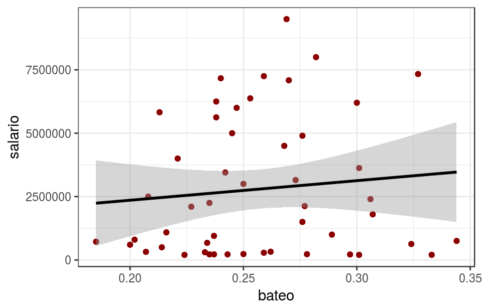

```r
ggplot(data = datos, mapping = aes(x = bateo, y = salario)) +
    geom_point(colour = "darkred") +
    geom_smooth(method = "lm", colour = "black") +
    theme_bw()
```

```r
cor(x = datos$bateo, y = datos$salario, method = "pearson")
```

```
## [1] 0.1067575
```

El cálculo de la correlación lineal de *Pearson* muestran un *r = 0.107*. ¿Es significativa está correlación?

**Distribución bootstrappig del coeficiente de correlación**

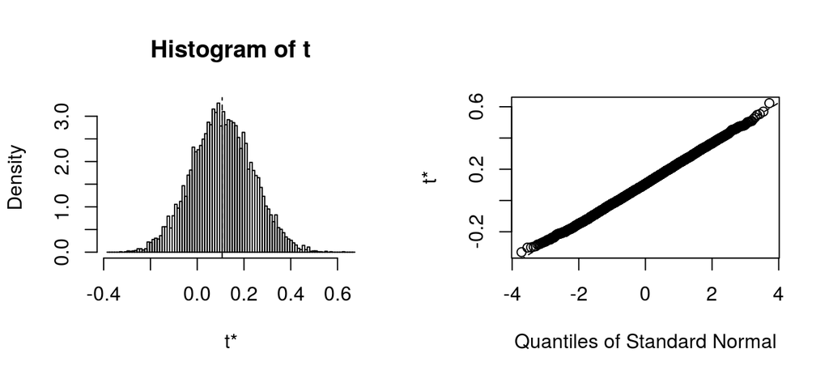

```
##
## 95.00% bca Confidence Interval, 9999 replicates
## Stat        CI (Low)    CI (High)   bias        SE
## 0.107       -0.144      0.363       0.001       0.129
```

```r
# Por defecto, si a la función bootES() se le pasan dos columnas numéricas, calcula
# el intervalo de confianza para el coeficiente de correlación de Pearson.
bootES(data = datos[c("bateo", "salario")], R = 9999, ci.type = "bca", plot = TRUE)
```

Dado que el intervalo de confianza del 95% contiene el valor 0, no se puede considerar significativa la correlación para un $\alpha$ de 0.05.